# Tyler Rinker

##### cm_code.overlap Examples

[`cm_code.overlap`](http://trinker.github.io/qdap_dev/cm_code.overlap.html) provides all the spans (time/words) that are occupied by all of the given codes. For example, if we utilized [`cm_code.overlap`](http://trinker.github.io/qdap_dev/cm_code.overlap.html) on code list X and Y the result would be any span where X and Y are both located. This is the AND of the Boolean search. Note that `overlap.code.list` must be supplied as a list of named character vectors.

♦ **[`cm_code.overlap`](http://trinker.github.io/qdap_dev/cm_code.overlap.html) Single Time** *Word Example*♦

```r
(co1 <- cm_code.overlap(x, list(BC=qcv(BB, CC))))
```

```
  code start end
1   AA     0  10
2   BB     0  10
3   BB    18  19
4   CC     0   3
5   CC     4   6
6   BC     0   3
7   BC     4   6
```

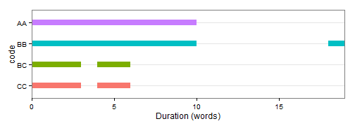

♦ **[`cm_code.overlap`](http://trinker.github.io/qdap_dev/cm_code.overlap.html) Repeated Measures** *Word Example*♦

```r
overlist <- list(AB=qcv(AA, BB), ABC=qcv(AA, BB, CC))
(co2 <- cm_code.overlap(z, overlist, rm.var = "time"))
```

```
   code start end time
1    AA     0  10  foo
2    BB     0  10  foo
3    BB    18  19  foo
4    CC     0   3  foo
5    CC     4   6  foo
6    AB     0  10  foo
7   ABC     0   3  foo
8   ABC     4   6  foo
9    AA     3   8 foo2
10   BB     0   4 foo2
11   BB     9  12 foo2
12   CC     0   1 foo2
13   CC    10  11 foo2
14   CC    14  20 foo2
15   AB     3   4 foo2
```

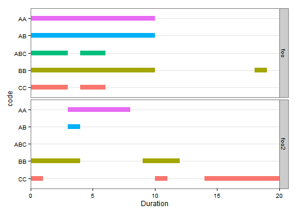

♦ **[`cm_code.overlap`](http://trinker.github.io/qdap_dev/cm_code.overlap.html) Repeated Measures** *Time Span Example*♦

```r
overlist2 <- list(AB=qcv(A, B), BC=qcv(B, C), ABC=qcv(A, B, C))
(co3 <- cm_code.overlap(dats, overlist2, "time"))
```

```
   code start  end    Start      End time
1     A   159  180 00:02:39 00:03:00 bar1
2     A   300  301 00:05:00 00:05:01 bar1
3     A   361  420 00:06:01 00:07:00 bar1
4     A   539  540 00:08:59 00:09:00 bar1
5     B   159  160 00:02:39 00:02:40 bar1
6     B   180  182 00:03:00 00:03:02 bar1
7     B   300  301 00:05:00 00:05:01 bar1
8     B   361  420 00:06:01 00:07:00 bar1
9     B   539  540 00:08:59 00:09:00 bar1
10    B  4319 4741 01:11:59 01:19:01 bar1
11    C   159  180 00:02:39 00:03:00 bar1
12    C   300  301 00:05:00 00:05:01 bar1
13    C   361  420 00:06:01 00:07:00 bar1
14    C   539  540 00:08:59 00:09:00 bar1
```

[output cut: 40 more lines]

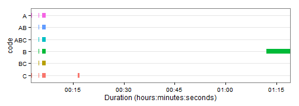

##### [`cm_code.transform`](http://trinker.github.io/qdap_dev/cm_code.transform.html) Examples

[`cm_code.transform`](http://trinker.github.io/qdap_dev/cm_code.transform.html) is merely a wrapper for [`cm_code.combine`](http://trinker.github.io/qdap_dev/cm_code.combine.html), [`cm_code.exclude`](http://trinker.github.io/qdap_dev/cm_code.exclude.html), and [`cm_code.overlap`](http://trinker.github.io/qdap_dev/cm_code.overlap.html).

♦ **[`cm_code.transform`](http://trinker.github.io/qdap_dev/cm_code.transform.html)** - Example 1♦

```r
ct1 <- cm_code.transform(x,
    overlap.code.list = list(oABC=qcv(AA, BB, CC)),
    combine.code.list = list(ABC=qcv(AA, BB, CC)),
    exclude.code.list = list(ABnoC=qcv(AA, BB, CC))
)
ct1
```

```
    code start end
1     AA     0  10
2     BB     0  10
3     BB    18  19
4     CC     0   3
5     CC     4   6
6   oABC     0   3
7   oABC     4   6
8    ABC     0  10
9    ABC    18  19
10 ABnoC     3   4
11 ABnoC     6  10
12 ABnoC    18  19
```

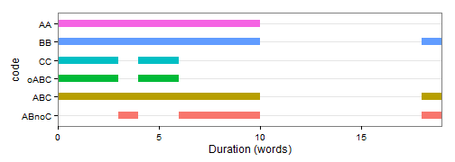

♦ **[`cm_code.transform`](http://trinker.github.io/qdap_dev/cm_code.transform.html)** - Example 2♦

```r
ct2 <-cm_code.transform(z,
    overlap.code.list = list(oABC=qcv(AA, BB, CC)),
    combine.code.list = list(ABC=qcv(AA, BB, CC)),
    exclude.code.list = list(ABnoC=qcv(AA, BB, CC)), "time"
)
ct2
```

```
    code start end time
1     AA     0  10  foo
2     BB     0  10  foo
3     BB    18  19  foo
4     CC     0   3  foo
5     CC     4   6  foo
6   oABC     0   3  foo
7   oABC     4   6  foo
14   ABC     0  10  foo
15   ABC    18  19  foo
19 ABnoC     3   4  foo
20 ABnoC     6  10  foo
21 ABnoC    18  19  foo
8     AA     3   8 foo2
9     BB     0   4 foo2
10    BB     9  12 foo2
11    CC     0   1 foo2
12    CC    10  11 foo2
13    CC    14  20 foo2
16   ABC     0   8 foo2
17   ABC     9  12 foo2
18   ABC    14  20 foo2
22 ABnoC     1   8 foo2
23 ABnoC     9  10 foo2
24 ABnoC    11  12 foo2
```

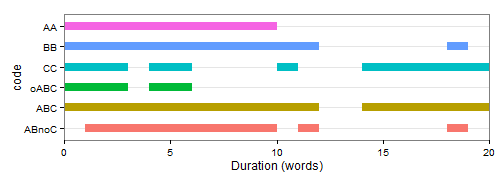

♦ **[`cm_code.transform`](http://trinker.github.io/qdap_dev/cm_code.transform.html)** - Example 3♦

```r
ct3 <-cm_code.transform(dat,
    overlap.code.list = list(oABC=qcv(A, B, C)),
    combine.code.list = list(ABC=qcv(A, B, C)),
    exclude.code.list = list(ABnoC=qcv(A, B, C))
)
ct3
```

```
    code start  end    Start      End
1      A   159  180 00:02:39 00:03:00
2      A   300  301 00:05:00 00:05:01
3      A   361  420 00:06:01 00:07:00
4      A   539  540 00:08:59 00:09:00
5      B   159  160 00:02:39 00:02:40
6      B   180  182 00:03:00 00:03:02
7      B   300  301 00:05:00 00:05:01
8      B   361  420 00:06:01 00:07:00
9      B   539  540 00:08:59 00:09:00
10     B  4319 4741 01:11:59 01:19:01
11     C   159  180 00:02:39 00:03:00
12     C   300  301 00:05:00 00:05:01
13     C   361  420 00:06:01 00:07:00
14     C   539  540 00:08:59 00:09:00
15     C   984 1021 00:16:24 00:17:01
16  oABC   159  160 00:02:39 00:02:40
17  oABC   300  301 00:05:00 00:05:01
18  oABC   361  420 00:06:01 00:07:00
19  oABC   539  540 00:08:59 00:09:00
20   ABC   159  182 00:02:39 00:03:02
21   ABC   300  301 00:05:00 00:05:01
22   ABC   361  420 00:06:01 00:07:00
23   ABC   539  540 00:08:59 00:09:00
24   ABC   984 1021 00:16:24 00:17:01
25   ABC  4319 4741 01:11:59 01:19:01
26 ABnoC   180  182 00:03:00 00:03:02
27 ABnoC  4319 4741 01:11:59 01:19:01
```

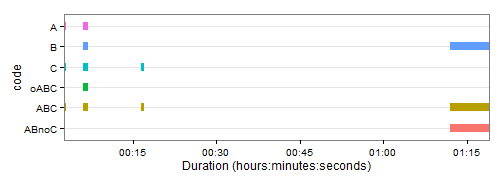

##### cm_code.blank Examples

[`cm_code.blank`](http://trinker.github.io/qdap_dev/cm_code.blank.html) provides flexible Boolean comparisons between word.time spans. The `overlap` argument takes a logical value, an integer or a character string of binary operator couple with an integer. It is important to understand how the function operates. This initial step calls [`cm_long2dummy`](http://trinker.github.io/qdap_dev/cm_long2dummy.html) as seen below (stretching the spans to dummy coded columns), the comparison is conduted between columns, and then the columns are reverted back to spans via the `cm)dummy2long`. This first example illustrates the stretching to dummy and reverting back to spans.

♦ **Long to dummy and dummy to long** ♦

```r
long2dummy <- cm_long2dummy(x, "variable")
list(original =x,
    long_2_dummy_format = long2dummy[[1]],
    dummy_back_2_long = cm_dummy2long(long2dummy, "variable")
)
```

```
$original
  code start end variable
1   AA     0  10      foo
2   BB     0   2      foo
3   BB     2  10      foo
4   BB    18  19      foo
5   CC     0   3      foo
6   CC     4   6      foo

$long_2_dummy_format
   AA BB CC
0   1  1  1
1   1  1  1
2   1  1  1
3   1  1  0
```

[output cut: 24 more lines]

Now let's examine a few uses of [`cm_code.blank`](http://trinker.github.io/qdap_dev/cm_code.blank.html). The first is to set `overlap = TRUE` (the default behavior). This default behavior is identical to [`cm_code.overlap`](http://trinker.github.io/qdap_dev/cm_code.overlap.html) as seen below.

♦ **[`cm_code.blank`](http://trinker.github.io/qdap_dev/cm_code.blank.html)** - `overlap = TRUE` ♦

```r
(cb1 <- cm_code.blank(x, list(ABC=qcv(AA, BB, CC))))
```

```
  code start end
1   AA     0  10
2   BB     0  10
3   BB    18  19
4   CC     0   3
5   CC     4   6
6  ABC     0   3
7  ABC     4   6
```

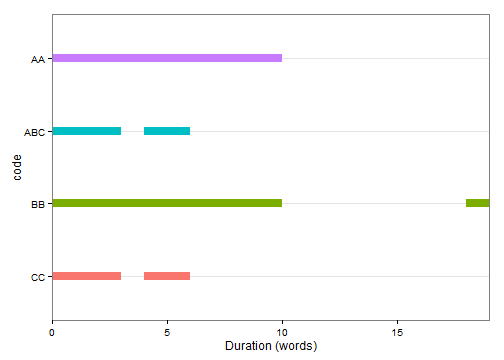

Next we'll set `overlap = FALSE` and see that it is identical to [`cm_code.combine`](http://trinker.github.io/qdap_dev/cm_code.combine.html).

♦ **[`cm_code.blank`](http://trinker.github.io/qdap_dev/cm_code.blank.html)** - `overlap = FALSE` ♦

```r
(cb2 <- cm_code.blank(x, list(ABC=qcv(AA, BB, CC)), overlap = FALSE))
```

```
  code start end
1   AA     0  10
2   BB     0  10
3   BB    18  19
4   CC     0   3
5   CC     4   6
6  ABC     0  10
7  ABC    18  19
```

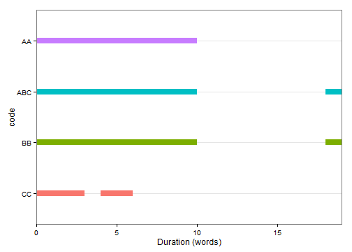

By first combining all codes (see `cb2` above) and then excluding the final code by setting `overlap = 1` the behavior of [`cm_code.exclude`](http://trinker.github.io/qdap_dev/cm_code.exclude.html) can be mimicked.

♦ **[`cm_code.blank`](http://trinker.github.io/qdap_dev/cm_code.blank.html)** - *mimicking [`cm_code.exclude`](http://trinker.github.io/qdap_dev/cm_code.exclude.html)* ♦

```r
## Using the output from `cb2` above.
(cb3 <- cm_code.blank(cb2, list(ABnoC=qcv(ABC, CC)), overlap = 1))
```

```
    code start end
1     AA     0  10
2     BB     0  10
3     BB    18  19
4     CC     0   3
5     CC     4   6
6    ABC     0  10
7    ABC    18  19
8  ABnoC     3   4
9  ABnoC     6  10
10 ABnoC    18  19
```

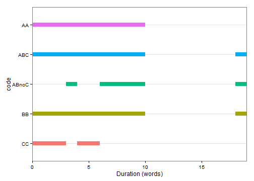

Next we shall find when at least two codes overlap by setting `overlap = ">1"`.

♦ **[`cm_code.blank`](http://trinker.github.io/qdap_dev/cm_code.blank.html)** - *At least 2 codes overlap* ♦

```r
blanklist <- list(AB=qcv(AA, BB), ABC=qcv(AA, BB, CC))
(cb4 <- cm_code.blank(z, blanklist, rm.var = "time", overlap = ">1"))
```

```
   code start end time
1    AA     0  10  foo
2    BB     0  10  foo
3    BB    18  19  foo
4    CC     0   3  foo
5    CC     4   6  foo
6    AB     0  10  foo
7   ABC     0  10  foo
8    AA     3   8 foo2
9    BB     0   4 foo2
10   BB     9  12 foo2
11   CC     0   1 foo2
12   CC    10  11 foo2
13   CC    14  20 foo2
14   AB     3   4 foo2
15  ABC     0   1 foo2
16  ABC     3   4 foo2
17  ABC    10  11 foo2
```

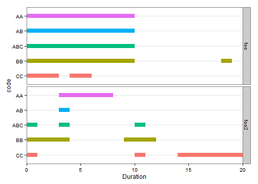

Last, we will find spans where not one of the codes occurred by setting `overlap = "==0"`.

♦ **[`cm_code.blank`](http://trinker.github.io/qdap_dev/cm_code.blank.html)** - *Spans where no code occurs* ♦

```r
blanklist2 <- list(noAB=qcv(AA, BB), noABC=qcv(AA, BB, CC))
(cb5 <- cm_code.blank(z, blanklist2, rm.var = "time", overlap = "==0"))
```

```
    code start end time
1     AA     0  10  foo
2     BB     0  10  foo
3     BB    18  19  foo
4     CC     0   3  foo
5     CC     4   6  foo
6   noAB    10  18  foo
7   noAB    19  20  foo
8  noABC    10  18  foo
9  noABC    19  20  foo
10    AA     3   8 foo2
11    BB     0   4 foo2
12    BB     9  12 foo2
13    CC     0   1 foo2
14    CC    10  11 foo2
15    CC    14  20 foo2
16  noAB     8   9 foo2
17  noAB    12  21 foo2
18 noABC     8   9 foo2
19 noABC    12  14 foo2
20 noABC    20  21 foo2
```

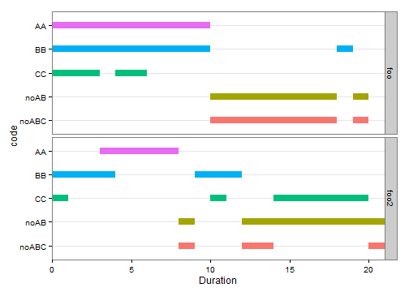

#### Initial Coding Analysis

The cm_ family of functions has three approaches to initial analysis of codes. The researcher may want to summarize, visualize or determine the proximity of codes to one another. The following functions accomplish these tasks:

1. Summary
2. Plotting
3. Distance Measures

##### Summary

Most of the cm_ family of functions have a [`summary`](http://trinker.github.io/qdap_dev/summary.cmspans.html) method to allows for summaries of codes by group. Note that these summaries can be wrapped with [`plot`](http://trinker.github.io/qdap_dev/plot.sum_cmspans.html) to print a heat map of the table of summaries.

♦ **Example 1: Summarizing Transcript/List Approach** ♦

```r
## Two transcript lists
A <- list(
    person_greg = qcv(terms='7:11, 20:24, 30:33, 49:56'),
    person_researcher = qcv(terms='42:48'),
    person_sally = qcv(terms='25:29, 37:41'),
    person_sam = qcv(terms='1:6, 16:19, 34:36'),
    person_teacher = qcv(terms='12:15'),
    adult_0 = qcv(terms='1:11, 16:41, 49:56'),
    adult_1 = qcv(terms='12:15, 42:48'),
    AA = qcv(terms="1"),
    BB = qcv(terms="1:2, 3:10, 19"),
    CC = qcv(terms="1:9, 100:150")
)

B  <- list(
    person_greg = qcv(terms='7:11, 20:24, 30:33, 49:56'),
    person_researcher = qcv(terms='42:48'),
    person_sally = qcv(terms='25:29, 37:41'),
    person_sam = qcv(terms='1:6, 16:19, 34:36'),
    person_teacher = qcv(terms='12:15'),
    adult_0 = qcv(terms='1:11, 16:41, 49:56'),
    adult_1 = qcv(terms='12:15, 42:48'),
    AA = qcv(terms="40"),
    BB = qcv(terms="50:90"),
    CC = qcv(terms="60:90, 100:120, 150"),
    DD = qcv(terms="")
)

## Long format for transcript/list approach
v <- cm_2long(A, B, v.name = "time")
head(v)
```

```
               code start end time
1       person_greg     6  11    A
2       person_greg    19  24    A
3       person_greg    29  33    A
4       person_greg    48  56    A
5 person_researcher    41  48    A
6      person_sally    24  29    A
```

```r
## Summary of the data and plotting the summary
summary(v)
```

```
time              code total percent_total n percent_n  ave min max   mean(sd)
1  a       person_greg    22         12.0% 4     18.2%  5.5   4   8   5.5(1.7)
2  a person_researcher     7          3.8% 1      4.5%  7.0   7   7     7.0(0)
3  a      person_sally    10          5.4% 2      9.1%  5.0   5   5     5.0(0)
4  a        person_sam    13          7.1% 3     13.6%  4.3   3   6   4.3(1.5)
5  a    person_teacher     4          2.2% 1      4.5%  4.0   4   4     4.0(0)
6  a           adult_0    45         24.5% 3     13.6% 15.0   8  26  15.0(9.6)
7  a           adult_1    11          6.0% 2      9.1%  5.5   4   7   5.5(2.1)
8  a                AA     1           .5% 1      4.5%  1.0   1   1     1.0(0)
9  a                BB    11          6.0% 3     13.6%  3.7   1   8   3.7(3.8)
10 a                CC    60         32.6% 2      9.1% 30.0   9  51 30.0(29.7)
11 b       person_greg    22         10.6% 4     19.0%  5.5   4   8   5.5(1.7)
12 b person_researcher     7          3.4% 1      4.8%  7.0   7   7     7.0(0)
13 b      person_sally    10          4.8% 2      9.5%  5.0   5   5     5.0(0)
14 b        person_sam    13          6.3% 3     14.3%  4.3   3   6   4.3(1.5)
15 b    person_teacher     4          1.9% 1      4.8%  4.0   4   4     4.0(0)
16 b           adult_0    45         21.7% 3     14.3% 15.0   8  26  15.0(9.6)
17 b           adult_1    11          5.3% 2      9.5%  5.5   4   7   5.5(2.1)
18 b                AA     1           .5% 1      4.8%  1.0   1   1     1.0(0)
19 b                BB    41         19.8% 1      4.8% 41.0  41  41    41.0(0)
20 b                CC    53         25.6% 3     14.3% 17.7   1  31 17.7(15.3)
============================
Unit of measure: words
```

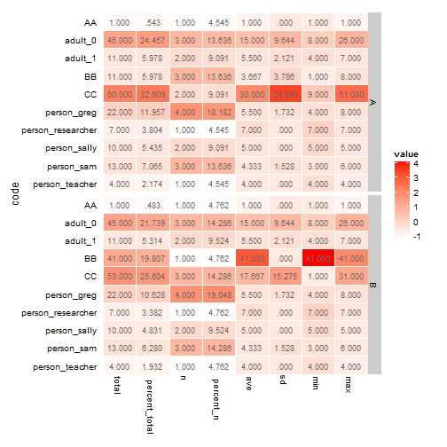

```r
plot(summary(v))
```

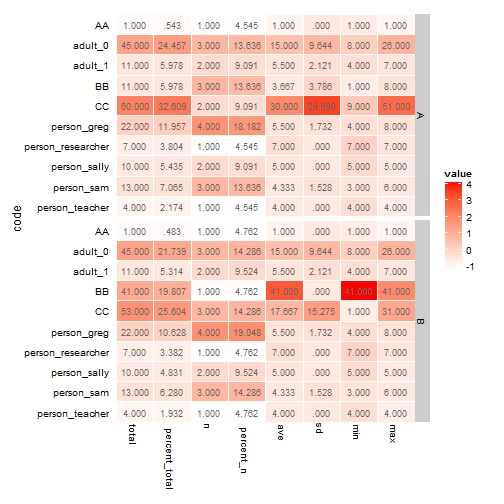

```r
plot(summary(v), facet.vars = "time")
```

♦ **Example 2: Summarizing Time Spans Approach** ♦

```r
## Single time list
x <- list(
    transcript_time_span = qcv(00:00 - 1:12:00),
    A = qcv(terms = "2.40:3.00, 5.01, 6.02:7.00, 9.00"),
    B = qcv(terms = "2.40, 3.01:3.02, 5.01, 6.02:7.00,
        9.00, 1.12.00:1.19.01"),
    C = qcv(terms = "2.40:3.00, 5.01, 6.02:7.00, 9.00, 17.01")
)

## Long format for time span approach
z <-cm_2long(x)
head(z)
```

```
##   code start end    Start      End variable
## 1    A   159 180 00:02:39 00:03:00        x
## 2    A   300 301 00:05:00 00:05:01        x
## 3    A   361 420 00:06:01 00:07:00        x
## 4    A   539 540 00:08:59 00:09:00        x
## 5    B   159 160 00:02:39 00:02:40        x
## 6    B   180 182 00:03:00 00:03:02        x
```

```r
## Summary of the data and plotting the summary
summary(z)
```

```
  code total percent_total n percent_n  ave min max    mean(sd)
1    A 01:22         12.6% 4     26.7% 20.5   1  59  20.5(27.3)
2    B 08:06         74.7% 6     40.0% 81.0   1 422 81.0(168.6)
3    C 01:23         12.7% 5     33.3% 16.6   1  59  16.6(25.2)
============================
Unit of measure: time
Columns measured in seconds unless in the form hh:mm:ss
```

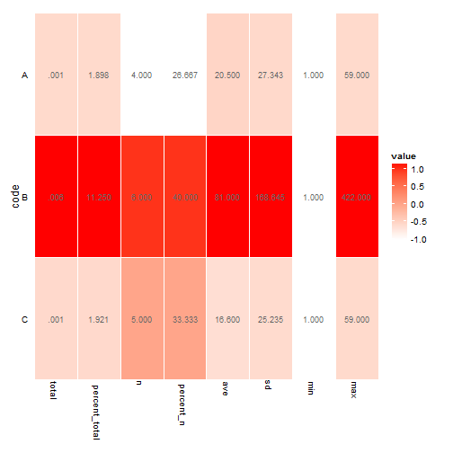

```r
plot(summary(z))
```

♦ **Trouble Shooting Summary: Suppress Measurement Units** ♦

```r
## suppress printing measurement units
suppressMessages(print(summary(z)))
```

```
  code total percent_total n percent_n  ave min max    mean(sd)
1    A 01:22         12.6% 4     26.7% 20.5   1  59  20.5(27.3)
2    B 08:06         74.7% 6     40.0% 81.0   1 422 81.0(168.6)
3    C 01:23         12.7% 5     33.3% 16.6   1  59  16.6(25.2)
```

♦ **Trouble Shooting Summary: Print as Dataframe** ♦

```r
## remove print method
class(z) <- "data.frame"
z
```

```
##    code start  end    Start      End variable
## 1     A   159  180 00:02:39 00:03:00        x
## 2     A   300  301 00:05:00 00:05:01        x
## 3     A   361  420 00:06:01 00:07:00        x
## 4     A   539  540 00:08:59 00:09:00        x
## 5     B   159  160 00:02:39 00:02:40        x
## 6     B   180  182 00:03:00 00:03:02        x
## 7     B   300  301 00:05:00 00:05:01        x
## 8     B   361  420 00:06:01 00:07:00        x
## 9     B   539  540 00:08:59 00:09:00        x
## 10    B  4319 4741 01:11:59 01:19:01        x
## 11    C   159  180 00:02:39 00:03:00        x
## 12    C   300  301 00:05:00 00:05:01        x
## 13    C   361  420 00:06:01 00:07:00        x
## 14    C   539  540 00:08:59 00:09:00        x
## 15    C  1020 1021 00:17:00 00:17:01        x
```

##### Plotting

Like [`summary`](http://trinker.github.io/qdap_dev/summary.cmspans.html), most of the cm_ family of functions have a [`plot`](http://trinker.github.io/qdap_dev/plot.cmspans.html) method as well that allows a Gantt plot visualization of codes by group.

♦ **Gantt Plot of Transcript/List or Time Spans Data** ♦

```r
## Two transcript lists
A <- list(
    person_greg = qcv(terms='7:11, 20:24, 30:33, 49:56'),
    person_researcher = qcv(terms='42:48'),
    person_sally = qcv(terms='25:29, 37:41'),
    person_sam = qcv(terms='1:6, 16:19, 34:36'),
    person_teacher = qcv(terms='12:15'),
    adult_0 = qcv(terms='1:11, 16:41, 49:56'),
    adult_1 = qcv(terms='12:15, 42:48'),
    AA = qcv(terms="1"),
    BB = qcv(terms="1:2, 3:10, 19"),
    CC = qcv(terms="1:9, 100:150")
)

B  <- list(
    person_greg = qcv(terms='7:11, 20:24, 30:33, 49:56'),
    person_researcher = qcv(terms='42:48'),
    person_sally = qcv(terms='25:29, 37:41'),
    person_sam = qcv(terms='1:6, 16:19, 34:36'),
    person_teacher = qcv(terms='12:15'),
    adult_0 = qcv(terms='1:11, 16:41, 49:56'),
    adult_1 = qcv(terms='12:15, 42:48'),
    AA = qcv(terms="40"),
    BB = qcv(terms="50:90"),
    CC = qcv(terms="60:90, 100:120, 150"),
    DD = qcv(terms="")
)

## Long format
x <- cm_2long(A, v.name = "time")
y <- cm_2long(A, B, v.name = "time")

## cm_code family
combs <- list(sam_n_sally = qcv(person_sam, person_sally))
z <- cm_code.combine(v, combs, "time")
```

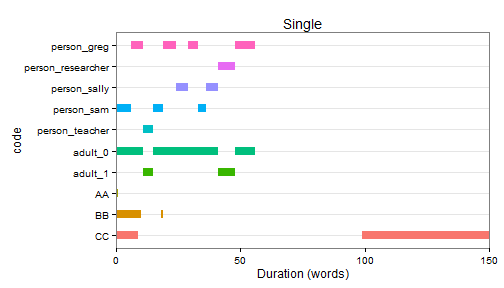

```r
plot(x, title = "Single")
```

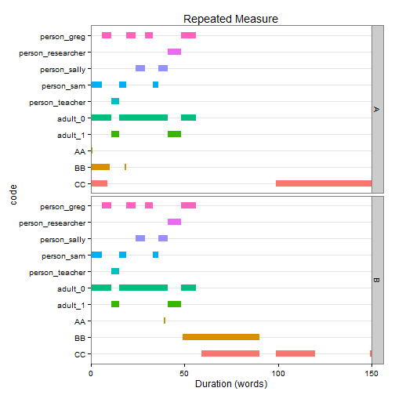

```r
plot(y, title = "Repeated Measure")
```

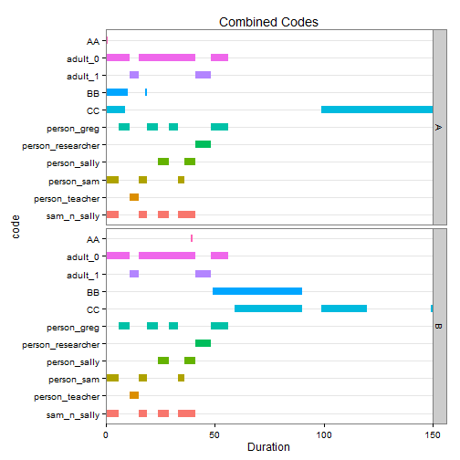

```r
plot(z, title = "Combined Codes")
```

##### Distance Measures

Often a research will want to know which codes are clustering closer to other codes (regardless of whether the codes represent word or time spans). [`cm_distance`](http://trinker.github.io/qdap_dev/cm_distance.html) allows the research to find the distances between codes and standardize the mean of the differences to allow for comparisons similar to a correlation. The matrix output from [`cm_distance`](http://trinker.github.io/qdap_dev/cm_distance.html) is arrived at by taking the means and standard deviations of the differences between codes and scaling them (without centering) and then multiplying the two together. This results in a standardized distance measure that is non-negative, with values closer to zero indicating codes that are found in closer proximity.

The researcher may also access the means, standard deviations and number of codes by indexing the list output for each transcript. This distance measure compliments the Gantt plot.

Note that the argument **causal = FALSE** (the default) does not assume Code A comes before Code B whereas **causal = TRUE** assumes the first code precedes the second code. Generally, setting **causal = FALSE** will result in larger mean of differences and accompanying standardized values. Also note that row names are the first code and column names are the second comparison code. The values for Code A compared to Code B will not be the same as Code B compared to Code A. This is because, unlike a true distance measure, [`cm_distance`](http://trinker.github.io/qdap_dev/cm_distance.html)'s matrix is asymmetrical. [`cm_distance`](http://trinker.github.io/qdap_dev/cm_distance.html)computes the distance by taking each span (start and end) for Code A and comparing it to the nearest start or end for Code B. So for example there may be 6 Code A spans and thus six differences between A and B, whereas Code B may only have 3 spans and thus three differences between B and A. This fact alone will lead to differences in A compared to B versus B compared to A.

♦ [`cm_distance`](http://trinker.github.io/qdap_dev/cm_distance.html) - *Initial Data Setup* ♦

```r
x <- list(
    transcript_time_span = qcv(00:00 - 1:12:00),
    A = qcv(terms = "2.40:3.00, 6.32:7.00, 9.00,
        10.00:11.00, 33.23:40.00, 59.56"),
    B = qcv(terms = "3.01:3.02, 5.01,  19.00, 1.12.00:1.19.01"),
    C = qcv(terms = "2.40:3.00, 5.01, 6.32:7.00, 9.00, 17.01, 38.09:40.00")
)
y <- list(
    transcript_time_span = qcv(00:00 - 1:12:00),
    A = qcv(terms = "2.40:3.00, 6.32:7.00, 9.00,
        10.00:11.00, 23.44:25.00, 59.56"),
    B = qcv(terms = "3.01:3.02, 5.01, 7.05:8.00 19.30, 1.12.00:1.19.01"),
    C = qcv(terms = "2.40:3.00, 5.01, 6.32:7.30, 9.00, 17.01, 25.09:27.00")
)

## Long format
dat <- cm_2long(x, y)
```

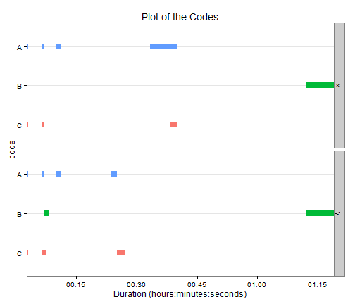

♦ [`cm_distance`](http://trinker.github.io/qdap_dev/cm_distance.html) - *Non-Causal Distance* ♦

```r
## a cm_distance output
(out1 <- cm_distance(dat, time.var = "variable"))
```

```
x

standardized:
     A    B    C
A 0.00 1.04 0.82
B 0.88 0.00 3.89
C 0.09 0.95 0.00


y

standardized:
     A    B    C
A 0.00 0.38 1.97
B 0.47 0.00 4.94
C 0.08 0.09 0.00
```

```r
## The elements available from the output
names(out1)
```

```
[1] "x" "y"
```

```r
## A list containing means, standard deviations and other
## descriptive statistics for the differences between codes
out1$x
```

```
$mean
       A      B      C
A   0.00 367.67 208.67
B 322.50   0.00 509.00
C  74.67 265.00   0.00

$sd
       A      B      C
A   0.00 347.51 483.27
B 337.47   0.00 940.94
C 143.77 440.92   0.00

$n
  A B C
A 6 6 6
B 4 4 4
C 6 6 6

$combined
  A                B                 C
A n=6              367.67(347.51)n=6 208.67(483.27)n=6
B 322.5(337.47)n=4 n=4               509(940.94)n=4
C 74.67(143.77)n=6 265(440.92)n=6    n=6

$standardized
     A    B    C
A 0.00 1.04 0.82
B 0.88 0.00 3.89
C 0.09 0.95 0.00
```

♦ [`cm_distance`](http://trinker.github.io/qdap_dev/cm_distance.html) - *Causal Distance* ♦

```r
## a cm_distance output `causal = TRUE`
cm_distance(dat, time.var = "variable", causal = TRUE)
```

```
x

standardized:
     A    B    C
A 0.66 0.84 0.08
B 0.29 3.96 0.49
C 0.40 0.86 0.37


y

standardized:
     A    B    C
A 1.11 1.63 0.08
B 0.03 2.95 0.04
C 0.70 1.27 0.11
```

### Word Counts and Descriptive Statistics

The following functions will be utilized in this section (click to view more):

- SPSS Style Frequency Tables

- Parts of Speech Tagging & Counts

- Question Type Counts

- Syllabication and Counts

- Convert/Generate Term Document Matrix or Document Term Matrix

- Search For and Count Terms

- Word Frequency Matrix

- Word & Character Counts

- Descriptive Word Statistics

A researcher often needs to quickly gather frequency counts for various words/word types. qdap offers multiple functions designed to efficiently generate descriptive word statistics by any combination of grouping variables. Many of the functions also offer proportional usage to more fairly compare between groups. Additionally, many functions also have plotting methods to better visualize the data that is transformed.

#### Descriptive Word Statistics

Often a researcher may want to get a general sense of how words are functioning for different grouping variables. The [`word_stats`](http://trinker.github.io/qdap_dev/word_stats.html) function enables a quick picture of what is occurring within the data. The displayed (printed) output is a dataframe, however, the output from word_stats is actually a list. Use [`?word_stats`](http://trinker.github.io/qdap_dev/word_stats.html) to learn more.

The displayed output is a wide dataframe, hence the abbreviated column names. The following column names and meanings will provide guidance in understanding the output:

##### [`word_stats`](http://trinker.github.io/qdap_dev/word_stats.html) Column Names

- n.tot - number of turns of talk
- n.sent - number of sentences
- n.words - number of words
- n.char - number of characters
- n.syl - number of syllables
- n.poly - number of polysyllables
- sptot - syllables per turn of talk
- wptot - words per turn of talk
- wps - words per sentence
- cps - characters per sentence
- sps - syllables per sentence
- psps - poly-syllables per sentence
- cpw - characters per word
- spw - syllables per word
- n.state - number of statements
- n.quest - number of questions
- n.exclm - number of exclamations
- n.incom - number of incomplete statements
- p.state - proportion of statements
- p.quest - proportion of questions
- p.exclm - proportion of exclamations
- p.incom - proportion of incomplete statements
- n.hapax - number of hapax legomenon
- n.dis - number of dis legomenon
- grow.rate - proportion of hapax legomenon to words
- prop.dis - proportion of dis legomenon to words

It is assumed you have run sentSplit on the data.  
If this is not the case the counts will not be accurate.

♦ **[`word_stats`](http://trinker.github.io/qdap_dev/word_stats.html) Example** ♦

Note that the initial output is broken into three dataframe outputs because of the width of printed output from [`word_stats`](http://trinker.github.io/qdap_dev/word_stats.html) being so large. The user will see that these three dataframes are actually one wide dataframe in the R output.

```r
(desc_wrds <- with(mraja1spl, word_stats(dialogue, person, tot = tot)))
```

```
           person n.tot n.sent n.words n.char n.syl n.poly sptot wptot
1           Romeo    49    113    1163   4757  1441     48   2.3  23.7
2        Benvolio    34     51     621   2563   780     25   1.5  18.3
3           Nurse    20     59     599   2274   724     20   3.0  29.9
4         Sampson    20     28     259    912   294      7   1.4  12.9
5          Juliet    16     24     206    789   238      5   1.5  12.9
6         Gregory    15     20     149    553   166      1   1.3   9.9
7         Capulet    14     72     736   2900   902     35   5.1  52.6
8    Lady Capulet    12     27     288   1205   370     10   2.2  24.0
9        Mercutio    11     24     549   2355   704     29   2.2  49.9
10        Servant    10     19     184    725   226      5   1.9  18.4
11         Tybalt     8     17     160    660   207      9   2.1  20.0
12       Montague     6     13     217    919   284     13   2.2  36.2
13        Abraham     5      6      24     79    26      0   1.2   4.8
14  First Servant     3      7      69    294    87      2   2.3  23.0
15 Second Servant     3      4      41    160    49      0   1.3  13.7
16  Lady Montague     2      4      28     88    30      0   2.0  14.0
17          Paris     2      3      32    124    41      2   1.5  16.0
18 Second Capulet     2      2      17     64    21      0   1.0   8.5
19         Prince     1      9     167    780   228     17   9.0 167.0
20  First Citizen     1      5      16     79    22      3   5.0  16.0
```

```
           person  wps  cps  sps psps cpw spw pspw n.state n.quest n.exclm
1           Romeo 10.3 42.1 12.8  0.4 4.1 1.2  0.0      69      22      22
2        Benvolio 12.2 50.3 15.3  0.5 4.1 1.3  0.0      39       8       4
3           Nurse 10.2 38.5 12.3  0.3 3.8 1.2  0.0      37       9      13
4         Sampson  9.2 32.6 10.5  0.2 3.5 1.1  0.0      27       1       0
5          Juliet  8.6 32.9  9.9  0.2 3.8 1.2  0.0      16       5       3
6         Gregory  7.5 27.6  8.3  0.0 3.7 1.1  0.0      14       3       3
7         Capulet 10.2 40.3 12.5  0.5 3.9 1.2  0.0      40      10      22
8    Lady Capulet 10.7 44.6 13.7  0.4 4.2 1.3  0.0      20       6       1
9        Mercutio 22.9 98.1 29.3  1.2 4.3 1.3  0.1      20       2       2
10        Servant  9.7 38.2 11.9  0.3 3.9 1.2  0.0      14       2       3
11         Tybalt  9.4 38.8 12.2  0.5 4.1 1.3  0.1      13       2       2
12       Montague 16.7 70.7 21.8  1.0 4.2 1.3  0.1      11       2       0
13        Abraham  4.0 13.2  4.3  0.0 3.3 1.1  0.0       3       2       1
14  First Servant  9.9 42.0 12.4  0.3 4.3 1.3  0.0       3       2       2
15 Second Servant 10.2 40.0 12.2  0.0 3.9 1.2  0.0       4       0       0
16  Lady Montague  7.0 22.0  7.5  0.0 3.1 1.1  0.0       2       2       0
17          Paris 10.7 41.3 13.7  0.7 3.9 1.3  0.1       2       1       0
18 Second Capulet  8.5 32.0 10.5  0.0 3.8 1.2  0.0       2       0       0
19         Prince 18.6 86.7 25.3  1.9 4.7 1.4  0.1       7       1       1
20  First Citizen  3.2 15.8  4.4  0.6 4.9 1.4  0.2       0       0       5
```

```
           person p.state p.quest p.exclm n.hapax n.dis grow.rate prop.dis
1           Romeo     0.6     0.2     0.2     365    84       0.3      0.1
2        Benvolio     0.8     0.2     0.1     252    43       0.4      0.1
3           Nurse     0.6     0.2     0.2     147    48       0.2      0.1
4         Sampson     1.0     0.0     0.0      81    22       0.3      0.1
5          Juliet     0.7     0.2     0.1      94    22       0.5      0.1
6         Gregory     0.7     0.2     0.2      72    17       0.5      0.1
7         Capulet     0.6     0.1     0.3     232    46       0.3      0.1
8    Lady Capulet     0.7     0.2     0.0     135    28       0.5      0.1
9        Mercutio     0.8     0.1     0.1     253    28       0.5      0.1
10        Servant     0.7     0.1     0.2      71    19       0.4      0.1
11         Tybalt     0.8     0.1     0.1      79    17       0.5      0.1
12       Montague     0.8     0.2     0.0     117    21       0.5      0.1
13        Abraham     0.5     0.3     0.2       3     7       0.1      0.3
14  First Servant     0.4     0.3     0.3      33     8       0.5      0.1
15 Second Servant     1.0     0.0     0.0      32     3       0.8      0.1
16  Lady Montague     0.5     0.5     0.0      24     2       0.9      0.1
17          Paris     0.7     0.3     0.0      25     2       0.8      0.1
18 Second Capulet     1.0     0.0     0.0       7     5       0.4      0.3
19         Prince     0.8     0.1     0.1      83    15       0.5      0.1
20  First Citizen     0.0     0.0     1.0       9     2       0.6      0.1
```

```r
## The following shows all the available elements in the `word_stats` output
names(desc_wrds)
```

```
## [1] "ts"        "gts"       "mpun"      "word.elem" "sent.elem" "omit"
## [7] "digits"
```

[`word_stats`](http://trinker.github.io/qdap_dev/word_stats.html) has a plot method that plots the output as a heat map. This can be useful for finding high/low elements in the data set.

♦ **[`word_stats`](http://trinker.github.io/qdap_dev/word_stats.html) Plot** ♦

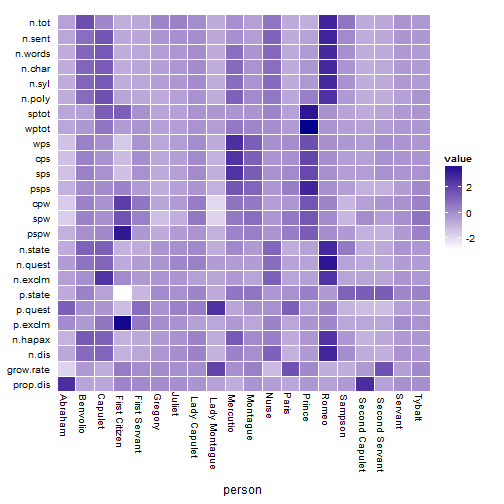

```r
plot(desc_wrds)
```

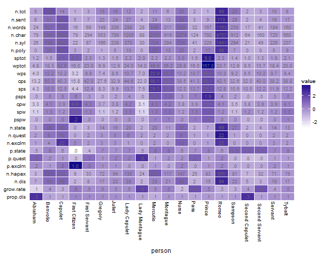

```r
plot(desc_wrds, label=TRUE, lab.digits = 1)
```

It takes considerable time to run [`word_stats`](http://trinker.github.io/qdap_dev/word_stats.html) because it is calculating syllable counts. The user may re-use the object output from one run and bass this as the text variable (`text.var`) in a subsequent run with different grouping variables (`grouping.vars`) as long as the text variable has not changed. The example below demonstrates how to re-use the output from one [`word_stats`](http://trinker.github.io/qdap_dev/word_stats.html) run in another run.

♦ **[`word_stats`](http://trinker.github.io/qdap_dev/word_stats.html) Re-use** ♦

```r
with(mraja1spl, word_stats(desc_wrds, list(sex, fam.aff, died), tot = tot))
```

#### Word Frequency Matrix

Many analyses with words involve a matrix based on the words. qdap uses a *word frequency matrix* ([`wfm`](http://trinker.github.io/qdap_dev/Word_Frequency_Matrix.html)) or the less malleable dataframe version, *word frequency dataframe* ([`wfdf`](http://trinker.github.io/qdap_dev/Word_Frequency_Matrix.html)). The [`wfm`](http://trinker.github.io/qdap_dev/Word_Frequency_Matrix.html) is a count of word usages per grouping variable(s). This is a similar concept to the [tm package's](http://cran.r-project.org/web/packages/tm/index.html) Term Document Matrix, though instead of documents we are interested in the grouping variable's usage of terms. [`wfm`](http://trinker.github.io/qdap_dev/Word_Frequency_Matrix.html) is the general function that should be used, however, the [`wfdf`](http://trinker.github.io/qdap_dev/Word_Frequency_Matrix.html) function does provide options for margin sums (row and column). Also note that the [`wfm_expanded`](http://trinker.github.io/qdap_dev/Word_Frequency_Matrix.html) and [`wfm_combine`](http://trinker.github.io/qdap_dev/Word_Frequency_Matrix.html) can expand or combine terms within a word frequency matrix.

♦ **[`wfm`](http://trinker.github.io/qdap_dev/Word_Frequency_Matrix.html) Examples** ♦

```r
## By a single grouping variable
with(DATA, wfm(state, person))[1:15, ]
```

```
##          greg researcher sally sam teacher
## about       0          0     1   0       0
## already     1          0     0   0       0
## am          1          0     0   0       0
## are         0          0     1   0       0
## be          0          0     1   0       0
## can         0          0     1   0       0
## certain     0          0     1   0       0
## computer    0          0     0   1       0
## distrust    0          0     0   1       0
## do          0          0     0   0       1
## dumb        1          0     0   0       0
## eat         1          0     0   0       0
## fun         0          0     0   2       0
## good        0          1     0   0       0
## how         0          0     1   0       0
```

```r
## By two grouping variables
with(DATA, wfm(state, list(sex, adult)))[1:15, ]
```

```
##          f.0 f.1 m.0 m.1
## about      1   0   0   0
## already    0   0   1   0
## am         0   0   1   0
## are        1   0   0   0
## be         1   0   0   0
## can        1   0   0   0
## certain    1   0   0   0
## computer   0   0   1   0
## distrust   0   0   1   0
## do         0   0   0   1
## dumb       0   0   1   0
## eat        0   0   1   0
## fun        0   0   2   0
## good       0   1   0   0
## how        1   0   0   0
```

♦ **[`wfm`](http://trinker.github.io/qdap_dev/Word_Frequency_Matrix.html): Keep Two Word Phrase as a Single Term** ♦

```r
## insert double tilde ("~~") to keep phrases(e. g., first last name)
space_keeps <- c(" fun", "I ")
state2 <- space_fill(DATA$state, space_keeps, rm.extra = FALSE)
with(DATA, wfm(state2, list(sex, adult)))[1:18, ]
```

```
##            f.0 f.1 m.0 m.1
## about        1   0   0   0
## already      0   0   1   0
## are          1   0   0   0
## be           1   0   0   0
## can          1   0   0   0
## certain      1   0   0   0
## computer     0   0   1   0
## do           0   0   0   1
## dumb         0   0   1   0
## eat          0   0   1   0
## good         0   1   0   0
## how          1   0   0   0
## hungry       0   0   1   0
## i'm          0   0   1   0
## i am         0   0   1   0
## i distrust   0   0   1   0
## is           0   0   1   0
## is fun       0   0   1   0
```

At times it may be useful to view the correlation between word occurrences between turns of talk or other useful groupings. The user can utilize the output from [`wfm`](http://trinker.github.io/qdap_dev/Word_Frequency_Matrix.html) to accomplish this.

♦ **[`wfm`](http://trinker.github.io/qdap_dev/Word_Frequency_Matrix.html): Word Correlations** ♦

```r
library(reports)
x <- factor(with(rajSPLIT, paste(act, pad(TOT(tot)), sep = "|")))
dat <- wfm(rajSPLIT$dialogue, x)
```

```r
cor(t(dat)[, c("romeo", "juliet")])
```

```
##            romeo    juliet
## romeo  1.0000000 0.1109808
## juliet 0.1109808 1.0000000
```

```r
cor(t(dat)[, c("romeo", "banished")])
```

```
##              romeo  banished
## romeo    1.0000000 0.3430018
## banished 0.3430018 1.0000000
```

```r
cor(t(dat)[, c("romeo", "juliet", "hate", "love")])
```

```
##             romeo       juliet        hate        love
## romeo   1.0000000  0.110980819 -0.04456250 0.208612442
## juliet  0.1109808  1.000000000 -0.03814941 0.005001955
## hate   -0.0445625 -0.038149408  1.00000000 0.158719658
## love    0.2086124  0.005001955  0.15871966 1.000000000
```

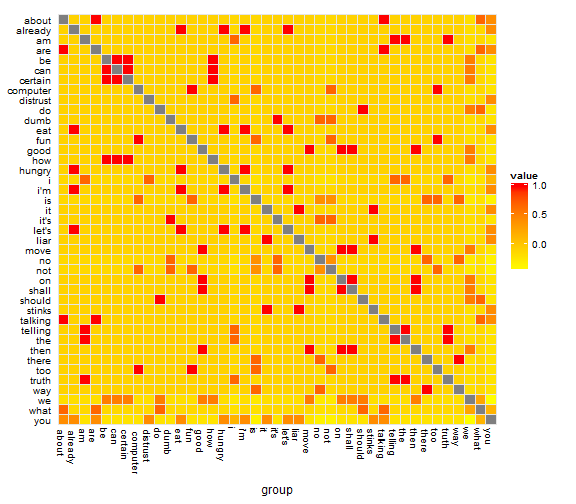

```r
dat2 <- wfm(DATA$state, id(DATA))
qheat(cor(t(dat2)), low = "yellow", high = "red",
    grid = "grey90", diag.na = TRUE, by.column = NULL)
```

♦ **[`wfdf`](http://trinker.github.io/qdap_dev/Word_Frequency_Matrix.html) Examples**: *Add Margins* ♦

```r
with(DATA, wfdf(state, person, margins = TRUE))[c(1:15, 41:42), ]
```

```
##             Words greg researcher sally sam teacher TOTAL.USES
## 1           about    0          0     1   0       0          1
## 2         already    1          0     0   0       0          1
## 3              am    1          0     0   0       0          1
## 4             are    0          0     1   0       0          1
## 5              be    0          0     1   0       0          1
## 6             can    0          0     1   0       0          1
## 7         certain    0          0     1   0       0          1
## 8        computer    0          0     0   1       0          1
## 9        distrust    0          0     0   1       0          1
## 10             do    0          0     0   0       1          1
## 11           dumb    1          0     0   0       0          1
## 12            eat    1          0     0   0       0          1
## 13            fun    0          0     0   2       0          2
## 14           good    0          1     0   0       0          1
## 15            how    0          0     1   0       0          1
## 41            you    1          0     1   2       0          4
## 42 TOTAL.WORDS ->   20          6    10  13       4         53
```

```r
with(DATA, wfdf(state, list(sex, adult), margins = TRUE))[c(1:15, 41:42), ]
```

```
##             Words f.0 f.1 m.0 m.1 TOTAL.USES
## 1           about   1   0   0   0          1
## 2         already   0   0   1   0          1
## 3              am   0   0   1   0          1
## 4             are   1   0   0   0          1
## 5              be   1   0   0   0          1
## 6             can   1   0   0   0          1
## 7         certain   1   0   0   0          1
## 8        computer   0   0   1   0          1
## 9        distrust   0   0   1   0          1
## 10             do   0   0   0   1          1
## 11           dumb   0   0   1   0          1
## 12            eat   0   0   1   0          1
## 13            fun   0   0   2   0          2
## 14           good   0   1   0   0          1
## 15            how   1   0   0   0          1
## 41            you   1   0   3   0          4
## 42 TOTAL.WORDS ->  10   6  33   4         53
```

♦ **[`wfm_expanded`](http://trinker.github.io/qdap_dev/Word_Frequency_Matrix.html): Expand the wfm** ♦

```r
## Start with a word frequency matrix
z <- wfm(DATA$state, DATA$person)

## Note a single `you`
z[30:41, ]
```

```
##         greg researcher sally sam teacher
## stinks     0          0     0   1       0
## talking    0          0     1   0       0
## telling    1          0     0   0       0
## the        1          0     0   0       0
## then       0          1     0   0       0
## there      1          0     0   0       0
## too        0          0     0   1       0
## truth      1          0     0   0       0
## way        1          0     0   0       0
## we         0          1     1   0       1
## what       0          0     1   0       1
## you        1          0     1   2       0
```

```r
## Note that there are two `you`s in the expanded version
wfm_expanded(z)[33:45, ]
```

```
##         greg researcher sally sam teacher
## stinks     0          0     0   1       0
## talking    0          0     1   0       0
## telling    1          0     0   0       0
## the        1          0     0   0       0
## then       0          1     0   0       0
## there      1          0     0   0       0
## too        0          0     0   1       0
## truth      1          0     0   0       0
## way        1          0     0   0       0
## we         0          1     1   0       1
## what       0          0     1   0       1
## you        1          0     1   1       0
## you        0          0     0   1       0
```

♦ **[`wfm_combine`](http://trinker.github.io/qdap_dev/Word_Frequency_Matrix.html): Combine Terms in the wfm** ♦

```r
## Start with a word frequency matrix
x <- wfm(DATA$state, DATA$person)

## The terms to exclude
WL <- list(
    random = c("the", "fun", "i"),
    yous = c("you", "your", "you're")
)

## Combine the terms
(out <- wfm_combine(x, WL))
```

```
##            greg researcher sally sam teacher
## random        2          0     0   3       0
## yous          1          0     1   2       0
## else.words   17          6     9   8       4
```

```r
## Pass the combined version to Chi Squared Test
chisq.test(out)
```

```
##
##  Pearson's Chi-squared test
##
## data:  out
## X-squared = 7.6609, df = 8, p-value = 0.4673
```

♦ **[`wfm`](http://trinker.github.io/qdap_dev/Word_Frequency_Matrix.html): Correspondence Analysis Example** ♦

```r
library(ca)

## Grab Just the Candidates
dat <- pres_debates2012
dat <- dat[dat$person %in% qcv(ROMNEY, OBAMA), ]

## Stem the text
speech <- stemmer(dat$dialogue)

## With 25 words removed
mytable1 <- with(dat, wfm(speech, list(person, time), stopwords = Top25Words))

## CA
fit <- ca(mytable)
summary(fit)
plot(fit)
plot3d.ca(fit, labels=1)

## With 200 words removed
mytable2 <- with(dat, wfm(speech, list(person, time), stopwords = Top200Words))

## CA
fit2 <- ca(mytable2)
summary(fit2)
plot(fit2)
plot3d.ca(fit2, labels=1)
```

##### Convert/Generate Term Document Matrix or Document Term Matrix

Some packages that could further the analysis of qdap expect a Document Term or Term Document Matrix. qdap's [`wfm`](http://trinker.github.io/qdap_dev/Word_Frequency_Matrix.html) is similar to the [tm package's](http://cran.r-project.org/web/packages/tm/index.html) [TermDocumentMatrix](http://www.inside-r.org/packages/cran/tm/docs/DocumentTermMatrix) and DocumentTermMatrix. qdap does not try to replicate the extensive work of the[tm](http://cran.r-project.org/web/packages/tm/index.html) package, however, the [`as.tdm`](http://trinker.github.io/qdap_dev/as.tdm.html) and [`as.dtm`](http://trinker.github.io/qdap_dev/as.tdm.html) do attempt to extend the work the researcher conducts in qdap to be utilized in other R packages. For a vignette describing qdap-tm compatability use `browseVignettes(package = "qdap")` or `\r HR2("http://cran.r-project.org/web/packages/qdap/vignettes/tm_package_compatibility.pdf, "Click Here")`.

♦ **[`as.tdm`](http://trinker.github.io/qdap_dev/as.tdm.html) Use** ♦

```r
x <- wfm(DATA$state, DATA$person)
## Term Document Matrix
as.tdm(x)
```

```
## <<TermDocumentMatrix (terms: 41, documents: 5)>>
## Non-/sparse entries: 49/156
## Sparsity           : 76%
## Maximal term length: 8
## Weighting          : term frequency (tf)
```

```r
## Document Term Matrix
as.dtm(x)
```

```
## <<DocumentTermMatrix (documents: 5, terms: 41)>>
## Non-/sparse entries: 49/156
## Sparsity           : 76%
## Maximal term length: 8
## Weighting          : term frequency (tf)
```

#### Search For and Count Terms

The [`termco`](http://trinker.github.io/qdap_dev/termco.html) family of functions are some of the most useful qdap functions for quantitative discourse analysis. [`termco`](http://trinker.github.io/qdap_dev/termco.html) searches for (an optionally groups) terms and outputs a raw count, percent, and combined (raw/percent) matrix of term counts by grouping variable. The [`term_match`](http://trinker.github.io/qdap_dev/termco.html) [`all_words`](http://trinker.github.io/qdap_dev/all_words.html) [`syn`](http://trinker.github.io/qdap_dev/synonyms.html), [`exclude`](http://trinker.github.io/qdap_dev/exclude.html), and [`spaste`](http://trinker.github.io/qdap_dev/spaste.html) are complementary functions that are useful in developing word lists to provide to the **match.list**.

The **match.list** acts to search for similarly grouped *themes*. For example c(“ read ”, “ reads”, “ reading”, “ reader”) may be a search for words associated with reading. It is good practice to name the vectors of words that are stored in the **match.list** . This is the general form for how to set up a **match.list**:

```r
themes <- list(
    theme_1 = c(),
    theme_2 = c(),
    theme_n = c()
)
```

It is important to understand how the **match.list** is handled by [`termco`](http://trinker.github.io/qdap_dev/termco.html). The **match.list** is (optionally) case and character sensitive. Spacing is an important way to grab specific words and requires careful thought. For example using “read” will find the words “bread”, “read”, “reading”, and “ready”. If you want to search for just the word “read” supply a vector of c(“ read ”, “ reads”, “ reading”, “ reader”). Notice the leading and trailing spaces. A space acts as a boundary whereas starting/ending with a nonspace allows for greedy matching that will find words that contain this term. A leading, trailing or both may be used to control how [`termco`](http://trinker.github.io/qdap_dev/termco.html) searches for the supplied terms. So the reader may ask why not supply one string spaced as “ read”? Keep in mind that [`termco`](http://trinker.github.io/qdap_dev/termco.html) would also find the word “ready”

This section's examples will first view the complementary functions that augment the *themes* supplied to **match.list** and then main [`termco`](http://trinker.github.io/qdap_dev/termco.html) function will be explored.

[`term_match`](http://trinker.github.io/qdap_dev/termco.html) looks through a text variable (usually the text found in the transcript) and finds/returns a vector of words containing a term(s).

♦ **[`term_match`](http://trinker.github.io/qdap_dev/termco.html) and [`exclude`](http://trinker.github.io/qdap_dev/exclude.html) Examples**♦

```r
term_match(text.var = DATA$state, terms = qcv(the, trust), return.list = FALSE)
```

```
## [1] "distrust" "the"      "then"     "there"
```

```r
term_match(DATA$state, "i", FALSE)
```

```
##  [1] "certain"  "distrust" "i"        "i'm"      "is"       "it"
##  [7] "it's"     "liar"     "stinks"   "talking"  "telling"
```

```r
exclude(term_match(DATA$state, "i", FALSE), talking, telling)
```

```
## [1] "certain"  "distrust" "i"        "i'm"      "is"       "it"
## [7] "it's"     "liar"     "stinks"
```

[`all_words`](http://trinker.github.io/qdap_dev/all_words.html) is similar to [`term_match`](http://trinker.github.io/qdap_dev/termco.html), however, the function looks at all the words found in a text variable (usually the transcript text) and returns words that begin with or contain the term(s). The output can be arrange alphabetically or by frequency. The output is a dataframe which helps the researcher to make decisions with regard to frequency of word use.

♦ **[`all_words`](http://trinker.github.io/qdap_dev/all_words.html) Examples**♦

```r
x1 <- all_words(raj$dialogue, begins.with="re")
head(x1, 10)
```

```
##    WORD       FREQ
## 1  re            2
## 2  reach         1
## 3  read          6
## 4  ready         5
## 5  rearward      1
## 6  reason        5
## 7  reason's      1
## 8  rebeck        1
## 9  rebellious    1
## 10 receipt       1
```

```r
all_words(raj$dialogue, begins.with="q")
```

```
##    WORD        FREQ
## 1  qualities      1
## 2  quarrel       11
## 3  quarrelled     1
## 4  quarrelling    2
## 5  quarrels       1
## 6  quarter        1
## 7  queen          1
## 8  quench         2
## 9  question       2
## 10 quick          2
## 11 quickly        5
## 12 quiet          4
## 13 quinces        1
## 14 quit           1
## 15 quite          2
## 16 quivering      1
## 17 quivers        1
## 18 quote          1
## 19 quoth          5
```

```r
all_words(raj$dialogue, contains="conc")
```

```
##   WORD      FREQ
## 1 conceal'd    1
## 2 conceit      2
## 3 conceive     1
## 4 concludes    1
## 5 reconcile    1
```

```r
x2 <- all_words(raj$dialogue)
head(x2, 10)
```

```
##    WORD      FREQ
## 1  'tis         9
## 2  a          445
## 3  a'           1
## 4  abate        1
## 5  abbey        1
## 6  abed         1
## 7  abhorred     1
## 8  abhors       1
## 9  able         2
## 10 ableeding    1
```

```r
x3 <- all_words(raj$dialogue, alphabetical = FALSE)
head(x3, 10)
```

```
##    WORD FREQ
## 1  and   666
## 2  the   656
## 3  i     573
## 4  to    517
## 5  a     445
## 6  of    378
## 7  my    358
## 8  is    344
## 9  that  344
## 10 in    312
```

The [`synonyms`](http://trinker.github.io/qdap_dev/synonyms.html) (short hand: [`syn`](http://trinker.github.io/qdap_dev/synonyms.html)) function finds words that are synonyms of a given set of terms and returns either a list of vector that can be passed to [`termco`](http://trinker.github.io/qdap_dev/termco.html)'s **match.list**.

♦ **[`synonyms`](http://trinker.github.io/qdap_dev/synonyms.html) Examples**♦

```r
synonyms(c("the", "cat", "job", "environment", "read", "teach"))
```

```
## $cat.def_1
## [1] "feline"    "gib"       "grimalkin" "kitty"     "malkin"
##
## $cat.def_2
## [1] "moggy"
##
## $cat.def_3
## [1] "mouser" "puss"
##
## $cat.def_4
## [1] "pussy"
##
## $cat.def_5
## [1] "tabby"
##
## $job.def_1
##  [1] "affair"         "assignment"     "charge"         "chore"
##  [5] "concern"        "contribution"   "duty"           "enterprise"
##  [9] "errand"         "function"       "pursuit"        "responsibility"
## [13] "role"           "stint"          "task"           "undertaking"
## [17] "venture"        "work"
##
## $job.def_2
##  [1] "business"   "calling"    "capacity"   "career"     "craft"
##  [6] "employment" "function"   "livelihood" "metier"     "occupation"
## [11] "office"     "position"   "post"       "profession" "situation"
## [16] "trade"      "vocation"
##
## $job.def_3
##  [1] "allotment"   "assignment"  "batch"       "commission"  "consignment"
##  [6] "contract"    "lot"         "output"      "piece"       "portion"
## [11] "product"     "share"
##
## $environment.def_1
##  [1] "atmosphere"   "background"   "conditions"   "context"
##  [5] "domain"       "element"      "habitat"      "locale"
##  [9] "medium"       "milieu"       "scene"        "setting"
## [13] "situation"    "surroundings" "territory"
##
## $environment.def_2
```

[output cut: 16 more lines]

```
## [3] "decipher"                "discover"
## [5] "interpret"               "perceive the meaning of"
## [7] "see"                     "understand"
##
## $read.def_4
## [1] "display"  "indicate" "record"   "register" "show"
##
## $teach.def_1
##  [1] "advise"          "coach"           "demonstrate"
##  [4] "direct"          "discipline"      "drill"
##  [7] "edify"           "educate"         "enlighten"
## [10] "give lessons in" "guide"           "impart"
## [13] "implant"         "inculcate"       "inform"
## [16] "instil"          "instruct"        "school"
## [19] "show"            "train"           "tutor"
```

```r
head(syn(c("the", "cat", "job", "environment", "read", "teach"),
    return.list = FALSE), 30)
```

```
##  [1] "feline"         "gib"            "grimalkin"      "kitty"
##  [5] "malkin"         "moggy"          "mouser"         "puss"
##  [9] "pussy"          "tabby"          "affair"         "assignment"
## [13] "charge"         "chore"          "concern"        "contribution"
## [17] "duty"           "enterprise"     "errand"         "function"
## [21] "pursuit"        "responsibility" "role"           "stint"
## [25] "task"           "undertaking"    "venture"        "work"
## [29] "business"       "calling"
```

```r
syn(c("the", "cat", "job", "environment", "read", "teach"), multiwords = FALSE)
```

```
## $cat.def_1
## [1] "feline"    "gib"       "grimalkin" "kitty"     "malkin"
##
## $cat.def_2
## [1] "moggy"
##
## $cat.def_3
## [1] "mouser" "puss"
##
## $cat.def_4
## [1] "pussy"
##
## $cat.def_5
## [1] "tabby"
##
## $job.def_1
##  [1] "affair"         "assignment"     "charge"         "chore"
##  [5] "concern"        "contribution"   "duty"           "enterprise"
##  [9] "errand"         "function"       "pursuit"        "responsibility"
## [13] "role"           "stint"          "task"           "undertaking"
## [17] "venture"        "work"
##
## $job.def_2
##  [1] "business"   "calling"    "capacity"   "career"     "craft"
##  [6] "employment" "function"   "livelihood" "metier"     "occupation"
## [11] "office"     "position"   "post"       "profession" "situation"
## [16] "trade"      "vocation"
##
## $job.def_3
##  [1] "allotment"   "assignment"  "batch"       "commission"  "consignment"
##  [6] "contract"    "lot"         "output"      "piece"       "portion"
## [11] "product"     "share"
##
## $environment.def_1
##  [1] "atmosphere"   "background"   "conditions"   "context"
##  [5] "domain"       "element"      "habitat"      "locale"
##  [9] "medium"       "milieu"       "scene"        "setting"
## [13] "situation"    "surroundings" "territory"
##
## $environment.def_2
## [1] "sea"    "air"    "plants"
##
## $read.def_1
## [1] "peruse" "scan"   "study"
##
## $read.def_2
## [1] "announce" "declaim"  "deliver"  "recite"   "speak"    "utter"
##
## $read.def_3
## [1] "comprehend" "construe"   "decipher"   "discover"   "interpret"
## [6] "see"        "understand"
##
## $read.def_4
## [1] "display"  "indicate" "record"   "register" "show"
##
## $teach.def_1
##  [1] "advise"      "coach"       "demonstrate" "direct"      "discipline"
##  [6] "drill"       "edify"       "educate"     "enlighten"   "guide"
## [11] "impart"      "implant"     "inculcate"   "inform"      "instil"
## [16] "instruct"    "school"      "show"        "train"       "tutor"
```

♦ **[`termco`](http://trinker.github.io/qdap_dev/termco.html) - Simple Example**♦

```r
## Make a small dialogue data set
(dat2 <- data.frame(dialogue=c("@bryan is bryan good @br",
    "indeed", "@ brian"), person=qcv(A, B, A)))
```

```
##                   dialogue person
## 1 @bryan is bryan good @br      A
## 2                   indeed      B
## 3                  @ brian      A
```

```r
## The word list to search for
ml <- list(
    wrds=c("bryan", "indeed"),
    "@",
    bryan=c("bryan", "@ br", "@br")
)

## Search by person
with(dat2, termco(dialogue, person, match.list=ml))
```

```
##   person word.count       wrds         @     bryan
## 1      A          6  2(33.33%) 3(50.00%) 5(83.33%)
## 2      B          1 1(100.00%)         0         0
```

```r
## Search by person proportion output
with(dat2, termco(dialogue, person, match.list=ml, percent = FALSE))
```

```
##   person word.count    wrds      @  bryan
## 1      A          6  2(.33) 3(.50) 5(.83)
## 2      B          1 1(1.00)      0      0
```

♦ **[`termco`](http://trinker.github.io/qdap_dev/termco.html) - Romeo and Juliet Act 1 Example**♦

```r
## Word list to search for
## Note: In the last vector using "the" will actually
## include the other 3 versions
ml2 <- list(
    theme_1 = c(" the ", " a ", " an "),
    theme_2 = c(" I'" ),
    "good",
    the_words = c("the", " the ", " the", "the ")
)

(out <- with(raj.act.1,  termco(dialogue, person, ml2)))
```

```
##            person word.count   theme_1 theme_2     good   the_words
## 1         Abraham         24         0       0        0           0
## 2        Benvolio        621 32(5.15%) 2(.32%)  2(.32%) 123(19.81%)
## 3         Capulet        736 39(5.30%) 3(.41%)  3(.41%)  93(12.64%)
## 4   First Citizen         16 2(12.50%)       0        0  10(62.50%)
## 5   First Servant         69 8(11.59%)       0 1(1.45%)  20(28.99%)
## 6         Gregory        149  9(6.04%)       0        0  48(32.21%)
## 7          Juliet        206  5(2.43%) 1(.49%)  1(.49%)   20(9.71%)
## 8    Lady Capulet        286 20(6.99%)       0        0  63(22.03%)
## 9   Lady Montague         28  2(7.14%)       0        0           0
## 10       Mercutio        552 49(8.88%)       0  2(.36%) 146(26.45%)
## 11       Montague        217 12(5.53%)       0  1(.46%)  41(18.89%)
## 12          Nurse        598 44(7.36%) 1(.17%)  2(.33%) 103(17.22%)
## 13          Paris         32         0       0        0    1(3.12%)
## 14         Prince        167  8(4.79%)       0        0  35(20.96%)
## 15          Romeo       1164 56(4.81%) 3(.26%)  3(.26%) 142(12.20%)
## 16        Sampson        259 19(7.34%)       0  1(.39%)  70(27.03%)
## 17 Second Capulet         17         0       0        0           0
## 18 Second Servant         41  2(4.88%)       0 1(2.44%)   8(19.51%)
## 19        Servant        183 12(6.56%) 1(.55%)  1(.55%)  46(25.14%)
## 20         Tybalt        160 11(6.88%) 1(.62%)        0  24(15.00%)
```

```r
## Available elements in the termco output (use dat$...)
names(out)
```

```
## [1] "raw"          "prop"         "rnp"          "zero.replace"
## [5] "percent"      "digits"
```

```r
## Raw and proportion - useful for presenting in tables
out$rnp
```

```
##            person word.count   theme_1 theme_2     good   the_words
## 1         Abraham         24         0       0        0           0
## 2        Benvolio        621 32(5.15%) 2(.32%)  2(.32%) 123(19.81%)
## 3         Capulet        736 39(5.30%) 3(.41%)  3(.41%)  93(12.64%)
## 4   First Citizen         16 2(12.50%)       0        0  10(62.50%)
## 5   First Servant         69 8(11.59%)       0 1(1.45%)  20(28.99%)
## 6         Gregory        149  9(6.04%)       0        0  48(32.21%)
## 7          Juliet        206  5(2.43%) 1(.49%)  1(.49%)   20(9.71%)
## 8    Lady Capulet        286 20(6.99%)       0        0  63(22.03%)
## 9   Lady Montague         28  2(7.14%)       0        0           0
## 10       Mercutio        552 49(8.88%)       0  2(.36%) 146(26.45%)
## 11       Montague        217 12(5.53%)       0  1(.46%)  41(18.89%)
## 12          Nurse        598 44(7.36%) 1(.17%)  2(.33%) 103(17.22%)
## 13          Paris         32         0       0        0    1(3.12%)
## 14         Prince        167  8(4.79%)       0        0  35(20.96%)
## 15          Romeo       1164 56(4.81%) 3(.26%)  3(.26%) 142(12.20%)
## 16        Sampson        259 19(7.34%)       0  1(.39%)  70(27.03%)
## 17 Second Capulet         17         0       0        0           0
## 18 Second Servant         41  2(4.88%)       0 1(2.44%)   8(19.51%)
## 19        Servant        183 12(6.56%) 1(.55%)  1(.55%)  46(25.14%)
## 20         Tybalt        160 11(6.88%) 1(.62%)        0  24(15.00%)
```

```r
## Raw - useful for performing calculations
out$raw
```

```
##            person word.count theme_1 theme_2 good the_words
## 1         Abraham         24       0       0    0         0
## 2        Benvolio        621      32       2    2       123
## 3         Capulet        736      39       3    3        93
## 4   First Citizen         16       2       0    0        10
## 5   First Servant         69       8       0    1        20
## 6         Gregory        149       9       0    0        48
## 7          Juliet        206       5       1    1        20
## 8    Lady Capulet        286      20       0    0        63
## 9   Lady Montague         28       2       0    0         0
## 10       Mercutio        552      49       0    2       146
## 11       Montague        217      12       0    1        41
## 12          Nurse        598      44       1    2       103
## 13          Paris         32       0       0    0         1
## 14         Prince        167       8       0    0        35
## 15          Romeo       1164      56       3    3       142
## 16        Sampson        259      19       0    1        70
## 17 Second Capulet         17       0       0    0         0
## 18 Second Servant         41       2       0    1         8
## 19        Servant        183      12       1    1        46
## 20         Tybalt        160      11       1    0        24
```

```r
## Proportion - useful for performing calculations
out$prop
```

```
##            person word.count   theme_1   theme_2      good the_words
## 1         Abraham         24  0.000000 0.0000000 0.0000000  0.000000
## 2        Benvolio        621  5.152979 0.3220612 0.3220612 19.806763
## 3         Capulet        736  5.298913 0.4076087 0.4076087 12.635870
## 4   First Citizen         16 12.500000 0.0000000 0.0000000 62.500000
## 5   First Servant         69 11.594203 0.0000000 1.4492754 28.985507
## 6         Gregory        149  6.040268 0.0000000 0.0000000 32.214765
## 7          Juliet        206  2.427184 0.4854369 0.4854369  9.708738
## 8    Lady Capulet        286  6.993007 0.0000000 0.0000000 22.027972
## 9   Lady Montague         28  7.142857 0.0000000 0.0000000  0.000000
## 10       Mercutio        552  8.876812 0.0000000 0.3623188 26.449275
## 11       Montague        217  5.529954 0.0000000 0.4608295 18.894009
## 12          Nurse        598  7.357860 0.1672241 0.3344482 17.224080
## 13          Paris         32  0.000000 0.0000000 0.0000000  3.125000
## 14         Prince        167  4.790419 0.0000000 0.0000000 20.958084
## 15          Romeo       1164  4.810997 0.2577320 0.2577320 12.199313
## 16        Sampson        259  7.335907 0.0000000 0.3861004 27.027027
## 17 Second Capulet         17  0.000000 0.0000000 0.0000000  0.000000
## 18 Second Servant         41  4.878049 0.0000000 2.4390244 19.512195
## 19        Servant        183  6.557377 0.5464481 0.5464481 25.136612
## 20         Tybalt        160  6.875000 0.6250000 0.0000000 15.000000
```

♦ **Using [`termco`](http://trinker.github.io/qdap_dev/termco.html) with [`term_match`](http://trinker.github.io/qdap_dev/termco.html) and [`exclude`](http://trinker.github.io/qdap_dev/exclude.html)**♦

```r
## Example 1
termco(DATA$state, DATA$person, exclude(term_match(DATA$state, qcv(th),
    FALSE), "truth"))
```

```
##       person word.count       the      then    there
## 1       greg         20 2(10.00%)         0 1(5.00%)
## 2 researcher          6 1(16.67%) 1(16.67%)        0
## 3      sally         10         0         0        0
## 4        sam         13         0         0        0
## 5    teacher          4         0         0        0
```

```r
## Example 2
MTCH.LST <- exclude(term_match(DATA$state, qcv(th, i)), qcv(truth, stinks))
termco(DATA$state, DATA$person, MTCH.LST)
```

```
##       person word.count        th          i
## 1       greg         20 3(15.00%) 13(65.00%)
## 2 researcher          6 2(33.33%)          0
## 3      sally         10         0  4(40.00%)
## 4        sam         13         0 11(84.62%)
## 5    teacher          4         0          0
```

♦ **Using [`termco`](http://trinker.github.io/qdap_dev/termco.html) with [`syn`](http://trinker.github.io/qdap_dev/syn.html)**♦

```r
syns <- synonyms("doubt")
syns[1]
```

```
## $doubt.def_1
## [1] "discredit"          "distrust"           "fear"
## [4] "lack confidence in" "misgive"            "mistrust"
## [7] "query"              "question"           "suspect"
```

```r
termco(DATA$state, DATA$person, unlist(syns[1]))
```

```
##       person word.count discredit distrust fear query question
## 1       greg         20         0        0    0     0        0
## 2 researcher          6         0        0    0     0        0
## 3      sally         10         0        0    0     0        0
## 4        sam         13         0 1(7.69%)    0     0        0
## 5    teacher          4         0        0    0     0        0
```

```r
synonyms("doubt", FALSE)
```

```
##  [1] "discredit"          "distrust"           "fear"
##  [4] "lack confidence in" "misgive"            "mistrust"
##  [7] "query"              "question"           "suspect"
## [10] "apprehension"       "disquiet"           "incredulity"
## [13] "lack of faith"      "misgiving"          "qualm"
## [16] "scepticism"         "suspicion"          "be dubious"
## [19] "be uncertain"       "demur"              "fluctuate"
## [22] "hesitate"           "scruple"            "vacillate"
## [25] "waver"              "dubiety"            "hesitancy"
## [28] "hesitation"         "indecision"         "irresolution"
## [31] "lack of conviction" "suspense"           "uncertainty"
## [34] "vacillation"        "confusion"          "difficulty"
## [37] "dilemma"            "perplexity"         "problem"
## [40] "quandary"           "admittedly"         "assuredly"
## [43] "certainly"          "doubtless"          "doubtlessly"
## [46] "probably"           "surely"
```

```r
termco(DATA$state, DATA$person, list(doubt = synonyms("doubt", FALSE)))
```

```
##       person word.count    doubt
## 1       greg         20        0
## 2 researcher          6        0
## 3      sally         10        0
## 4        sam         13 1(7.69%)
## 5    teacher          4        0
```

```r
termco(DATA$state, DATA$person, syns)
```

```
##       person word.count doubt.def_1 doubt.def_2 doubt.def_5 doubt.def_6
## 1       greg         20           0           0           0           0
## 2 researcher          6           0           0           0           0
## 3      sally         10           0           0           0           0
## 4        sam         13    1(7.69%)    1(7.69%)           0           0
## 5    teacher          4           0           0           0           0
```

[`termco`](http://trinker.github.io/qdap_dev/termco.html) also has a plot method that plots a heat map of the [`termco`](http://trinker.github.io/qdap_dev/termco.html) output based on the percent usage by grouping variable. This allows for rapid visualizations of patterns and enables fast spotting of extreme values. Here are some plots from the Romeo and Juliet Act 1 Example above.

♦ **Using [`termco`](http://trinker.github.io/qdap_dev/termco.html) Plotting**♦

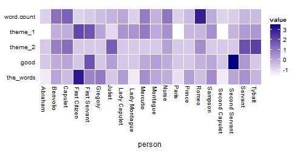

```r
plot(out)
```

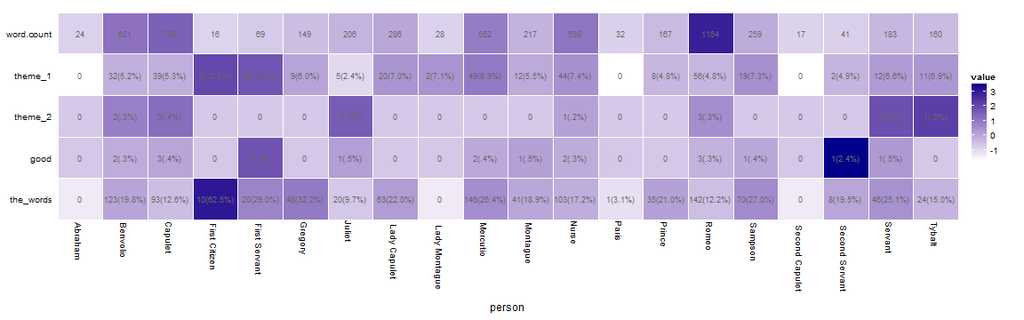

```r
plot(out, label = TRUE)
```

#### Question Type Counts

A researcher may be interested in classifying and investigating the types of questions used within dialogue.  
[`question_type`](http://trinker.github.io/qdap_dev/question_type.html) provides question classification. The algorithm searches for the following interrogative words (and optionally, their negative contraction form as well):

```
are*           had*           must*          what           why
can*           has            ok             when           will*
correct        have*          right          where          would*
could          how            shall          which          implied do/does/did
did*           is             should         who
do*            may            was*           whom
does*          might*         were*          whose
```

The interrogative word that is found first (with the exception of “ok”, “right” and “correct”) in the question determines the sentence type. “ok”, “right” and “correct” sentence types are determined if the sentence is a question with no other interrogative words found and “ok”, “right” or “correct” is the last word of the sentence. Those interrogative sentences beginning with the word “you”, “wanna”, or “want” are categorized as implying do/does/did question type, though the use of do/does is not explicit. Those sentence beginning with “you” followed by a select interrogative word (and or their negative counter parts) above (marked with *) or 1-2 amplifier(s) followed by the select interrogative word are categorized by the select word rather than an implied do/does/did question type. A sentence that is marked “ok” over rides an implied do/does/did label. Those with undetermined sentence type are labeled unknown.

♦ **[`question_type`](http://trinker.github.io/qdap_dev/question_type.html) - Basic Example**♦

```r
## Basic Example
(x <- question_type(DATA.SPLIT$state, DATA.SPLIT$person))
```

```
##       person tot.quest    what    how   shall implied_do/does/did
## 1       greg         1       0      0       0             1(100%)
## 2 researcher         1       0      0 1(100%)                   0
## 3      sally         2  1(50%) 1(50%)       0                   0
## 4    teacher         1 1(100%)      0       0                   0
## 5        sam         0       0      0       0                   0
```

```r
## Available elements from output
names(x)
```

```
## [1] "raw"          "count"        "prop"         "rnp"
## [5] "inds"         "missing"      "percent"      "zero.replace"
## [9] "digits"
```

```r
## Table of counts useful for additional analysis
x$count
```

```
##       person tot.quest what how shall implied_do/does/did
## 1       greg         1    0   0     0                   1
## 2 researcher         1    0   0     1                   0
## 3      sally         2    1   1     0                   0
## 4    teacher         1    1   0     0                   0
## 5        sam         0    0   0     0                   0
```

```r
## The raw output with question types
truncdf(x$raw, 15)
```

```
##       person        raw.text n.row endmark      strip.text          q.type
## 1    teacher What should we      4       ?  what should we            what
## 2      sally How can we be c     7       ?  how can we be              how
## 3      sally What are you ta    10       ?  what are you t            what
## 4 researcher Shall we move o    11       ?  shall we move            shall
## 5       greg    You already?    15       ?    you already  implied_do/does
```

[`question_type`](http://trinker.github.io/qdap_dev/question_type.html) also has a plot method that plots a heat map of the output. This allows for rapid visualizations of patterns and enables fast spotting of extreme values.

♦ **[`question_type`](http://trinker.github.io/qdap_dev/question_type.html) - Plotting Method**♦

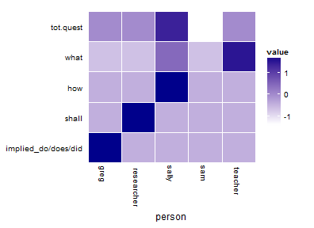

```r
plot(x)
```

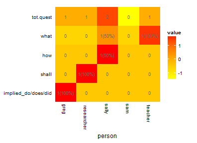

```r
plot(x, label = TRUE, high = "red", low = "yellow", grid = NULL)
```

Negative forms of questions such as Don't you want the robots to leave? are, by default, grouped with their equivalent positive Do forms, such as Do you want the robots to leave?. The researcher may choose to keep the two forms separate using the argument **neg.cont = TRUE**

♦ **[`question_type`](http://trinker.github.io/qdap_dev/question_type.html) - Include Negative Questions**♦

```r
## Create a Dataframe with Do and Don't
(DATA.SPLIT2 <- rbind(DATA.SPLIT,
    c("sam", "1.1", "1", "m", "0", "K1", "Don't you think so?", "x"),
    c("sam", "1.1", "1", "m", "0", "K1", "Do you think so?", "x")
))[, c(1, 7)]
```

```
##        person                       state
## 1         sam            Computer is fun.
## 2         sam                Not too fun.
## 3        greg     No it's not, it's dumb.
## 4     teacher          What should we do?
## 5         sam        You liar, it stinks!
## 6        greg     I am telling the truth!
## 7       sally      How can we be certain?
## 8        greg            There is no way.
## 9         sam             I distrust you.
## 10      sally What are you talking about?
## 11 researcher           Shall we move on?
## 12 researcher                  Good then.
## 13       greg                 I'm hungry.
## 14       greg                  Let's eat.
## 15       greg                You already?
## 16        sam         Don't you think so?
## 17        sam            Do you think so?
```

```r
## Do and Don't Grouped Together
question_type(DATA.SPLIT2$state, DATA.SPLIT2$person)
```

```
##       person tot.quest    what      do    how   shall implied_do/does/did
## 1       greg         1       0       0      0       0             1(100%)
## 2 researcher         1       0       0      0 1(100%)                   0
## 3      sally         2  1(50%)       0 1(50%)       0                   0
## 4        sam         2       0 2(100%)      0       0                   0
## 5    teacher         1 1(100%)       0      0       0                   0
```

```r
## Do and Don't Grouped Separately
question_type(DATA.SPLIT2$state, DATA.SPLIT2$person, neg.cont = TRUE)
```

```
      person tot.quest    what  don't     do    how   shall implied_do/does/did
1       greg         1       0      0      0      0       0             1(100%)
2 researcher         1       0      0      0      0 1(100%)                   0
3      sally         2  1(50%)      0      0 1(50%)       0                   0
4        sam         2       0 1(50%) 1(50%)      0       0                   0
5    teacher         1 1(100%)      0      0      0       0                   0
```

It may be helpful to access the indices of the question types in the **x[[“inds”]]** output or access **x[[“raw”]][, “n.row”]** for use with the **[`trans_context`](http://trinker.github.io/qdap_dev/trans_context.html)** function as seen below.

♦ **[`question_type`](http://trinker.github.io/qdap_dev/question_type.html) - Passing to [`trans_context`](http://trinker.github.io/qdap_dev/trans_context.html)**♦

```r
## The indices of all questions
x <- question_type(DATA.SPLIT$state, DATA.SPLIT$person)
(inds1 <- x[["inds"]])
```

```
## [1]  4  7 10 11 15
```

```r
with(DATA.SPLIT, trans_context(state, person, inds = inds1, n.before = 2))
```

```
===================================
Event 1: [lines 2-6]

    sam:        Computer is fun. Not too fun.

    greg:       No it's not, it's dumb.

 ** teacher:    What should we do?

    sam:        You liar, it stinks!

    greg:       I am telling the truth!

===================================
Event 2: [lines 5-9]

    sam:        You liar, it stinks!

    greg:       I am telling the truth!

 ** sally:      How can we be certain?

    greg:       There is no way.

    sam:        I distrust you.

===================================
Event 3: [lines 8-12]

    greg:       There is no way.

    sam:        I distrust you.

 ** sally:      What are you talking about?

    researcher: Shall we move on? Good then.

    greg:       I'm hungry. Let's eat. You already?

===================================
Event 4: [lines 9-13]

    sam:        I distrust you.

    sally:      What are you talking about?

 ** researcher: Shall we move on? Good then.

    greg:       I'm hungry. Let's eat. You already?

===================================
Event 5: [lines 13-15]

    sally:      What are you talking about?

    researcher: Shall we move on? Good then.

 ** greg:       I'm hungry. Let's eat. You already?
```

```r
## Find what and how questions
inds2 <- x[["raw"]][x[["raw"]]$q.type %in% c("what", "how"), "n.row"]
with(DATA.SPLIT, trans_context(state, person, inds = inds2, n.before = 2))
```

```
===================================
Event 1: [lines 2-6]

    sam:        Computer is fun. Not too fun.

    greg:       No it's not, it's dumb.

 ** teacher:    What should we do?

    sam:        You liar, it stinks!

    greg:       I am telling the truth!

===================================
Event 2: [lines 5-9]

    sam:        You liar, it stinks!

    greg:       I am telling the truth!

 ** sally:      How can we be certain?

    greg:       There is no way.

    sam:        I distrust you.

===================================
Event 3: [lines 8-12]

    greg:       There is no way.

    sam:        I distrust you.

 ** sally:      What are you talking about?

    researcher: Shall we move on? Good then.

    greg:       I'm hungry. Let's eat. You already?
```

#### Word & Character Counts

A research may have the need to view simple word or character counts for the sake of comparisons between grouping variables. [`word_count`](http://trinker.github.io/qdap_dev/word_count.html) ([`wc`](http://trinker.github.io/qdap_dev/word_count.html)), [`word_list`](http://trinker.github.io/qdap_dev/word_list.html), [`character_count`](http://trinker.github.io/qdap_dev/word_count.html), [`character_table`](http://trinker.github.io/qdap_dev/word_count.html) ([`char_table`](http://trinker.github.io/qdap_dev/word_count.html)) serve the purposes of counting words and characters with [`word_list`](http://trinker.github.io/qdap_dev/word_list.html) producing a lists of words usage by grouping variable and [`character_table`](http://trinker.github.io/qdap_dev/word_count.html) producing a count table of characters. The following examples demonstrate the uses of these functions.

♦ **[`word_count`](http://trinker.github.io/qdap_dev/word_count.html) Examples**♦

```r
word_count(DATA$state)
```

```
##  [1] 6 5 4 4 5 5 4 3 5 6 6
```

```r
## `wc a shortened version of `word_count`
wc(DATA$state)
```

```
##  [1] 6 5 4 4 5 5 4 3 5 6 6
```

```r
## Retain the text
wc(DATA$state, names = TRUE)
```

```
##         Computer is fun. Not too fun.
##                                     6
##               No it's not, it's dumb.
##                                     5
##                    What should we do?
##                                     4
##                  You liar, it stinks!
##                                     4
##               I am telling the truth!
##                                     5
##                How can we be certain?
##                                     5
##                      There is no way.
##                                     4
##                       I distrust you.
##                                     3
##           What are you talking about?
##                                     5
##         Shall we move on?  Good then.
##                                     6
## I'm hungry.  Let's eat.  You already?
##                                     6
```

```r
## Setting `byrow=FALSE` gives a total for the text variable
word_count(DATA$state, byrow=FALSE, names = TRUE)
```

```
## [1] 53
```

```r
## identical to `byrow=FALSE` above
sum(word_count(DATA$state))
```

```
## [1] 53
```

```r
## By grouping variable
tapply(DATA$state, DATA$person, wc, byrow=FALSE)
```

```
##       greg researcher      sally        sam    teacher
##         20          6         10         13          4
```

♦ **[`word_count`](http://trinker.github.io/qdap_dev/word_count.html) Plotting Centered Word Counts**♦

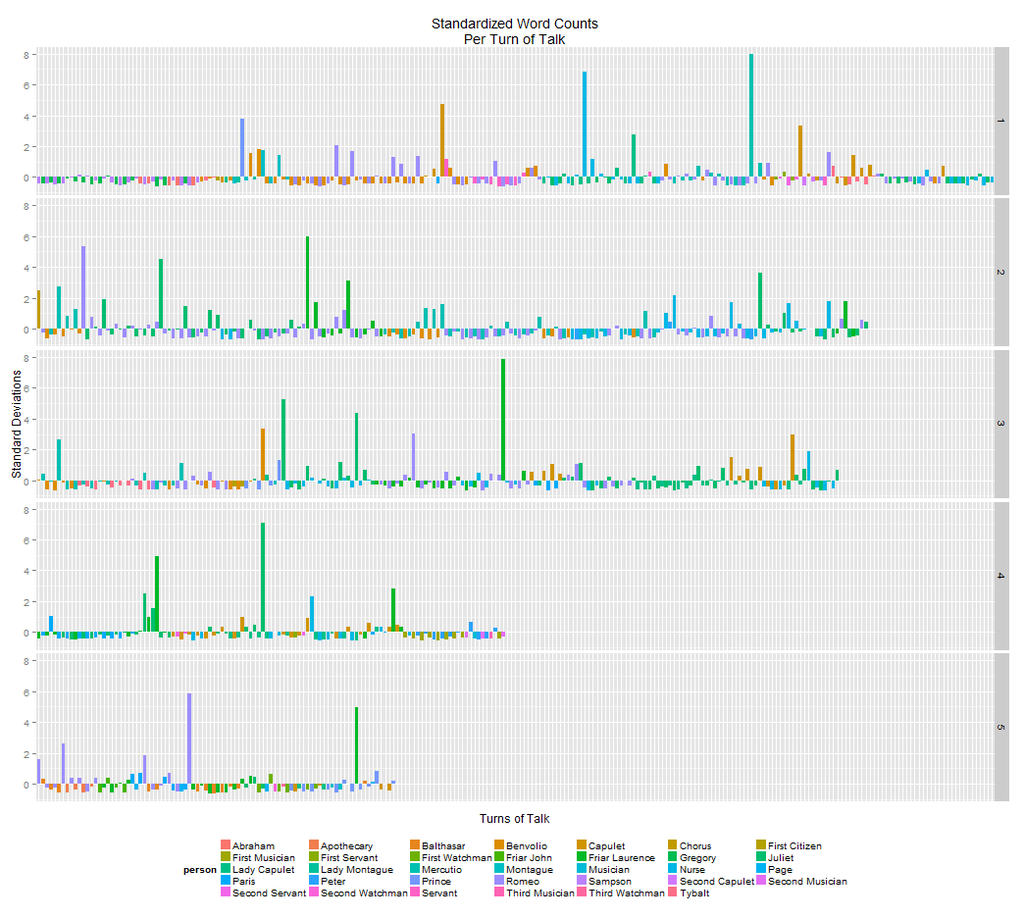

```r
## Scale variable
raj2 <- raj
raj2$scaled <- unlist(tapply(wc(raj$dialogue), raj2$act, scale))
raj2$scaled2 <- unlist(tapply(wc(raj$dialogue), raj2$act, scale, scale = FALSE))
raj2$ID <- factor(unlist(tapply(raj2$act, raj2$act, seq_along)))

## Plot with ggplot2
library(ggplot2); library(grid)
ggplot(raj2, aes(x = ID, y = scaled, fill =person)) +
    geom_bar(stat="identity", position="identity") +
    facet_grid(act~.) +
    ylab("Standard Deviations") + xlab("Turns of Talk") +
    guides(fill = guide_legend(nrow = 5, byrow = TRUE)) +
    theme(legend.position="bottom", legend.key.size = unit(.35, "cm"),
        axis.text.x = element_blank(), axis.ticks.x = element_blank()) +
    ggtitle("Standardized Word Counts\nPer Turn of Talk")
```

♦ **[`character_count`](http://trinker.github.io/qdap_dev/word_count.html) Examples**♦

```r
character_count(DATA$state)
```

```
##  [1] 22 17 14 15 18 17 12 12 22 21 27
```

```r
## Setting `byrow=FALSE` gives a total for the text variable
character_count(DATA$state, byrow=FALSE)
```

```
## [1] 197
```

```r
## identical to `byrow=FALSE` above
sum(character_count(DATA$state))
```

```
## [1] 197
```

```r
## By grouping variable
tapply(DATA$state, DATA$person, character_count, byrow=FALSE)
```

```
##       greg researcher      sally        sam    teacher
##         74         21         39         49         14
```

♦ **[`character_table`](http://trinker.github.io/qdap_dev/word_count.html) Example**♦

```r
x <- character_table(DATA$state, DATA$person)
names(x)
```

```
## [1] "raw"  "prop" "rnp"
```

```r
counts(x)
```

```
##       person '    ! , . ? a b c d e f g h i k l m n o p r s  t u v w y
## 1       greg 4 16 1 1 7 1 5 1 0 2 7 0 2 4 6 0 4 3 5 4 0 4 4 10 4 0 1 4
## 2 researcher 0  5 0 0 1 1 1 0 0 1 3 0 1 2 0 0 2 1 2 4 0 0 1  1 0 1 1 0
## 3      sally 0  8 0 0 1 2 6 2 2 0 4 0 1 2 2 1 1 0 3 3 0 2 0  4 2 0 3 1
## 4        sam 0 10 1 1 5 0 1 0 1 1 1 2 0 0 6 1 1 1 4 6 1 3 5  7 6 0 0 2
## 5    teacher 0  3 0 0 0 1 1 0 0 2 1 0 0 2 0 0 1 0 0 2 0 0 1  1 1 0 2 0
```

```r
proportions(x)[, 1:10]
```

```
##       person '                 !        ,        .        ?         a b        c
## 1       greg 4 16.00000 1.000000 1.000000 7.000000 1.000000  5.000000 1 0.000000
## 2 researcher 0 17.85714 0.000000 0.000000 3.571429 3.571429  3.571429 0 0.000000
## 3      sally 0 16.00000 0.000000 0.000000 2.000000 4.000000 12.000000 4 4.000000
## 4        sam 0 15.15152 1.515152 1.515152 7.575758 0.000000  1.515152 0 1.515152
## 5    teacher 0 16.66667 0.000000 0.000000 0.000000 5.555556  5.555556 0 0.000000
```

```r
scores(x)[, 1:7]
```

```
##       person     '                   !        ,        .        ?
## 1       greg 4(4%) 16(16.00%) 1(1.00%) 1(1.00%) 7(7.00%) 1(1.00%)
## 2 researcher     0  5(17.86%)        0        0 1(3.57%) 1(3.57%)
## 3      sally     0  8(16.00%)        0        0 1(2.00%) 2(4.00%)
## 4        sam     0 10(15.15%) 1(1.52%) 1(1.52%) 5(7.58%)        0
## 5    teacher     0  3(16.67%)        0        0        0 1(5.56%)
```

```r
## Combine Columns
vowels <- c("a", "e", "i", "o", "u")
cons <- letters[!letters %in% c(vowels, qcv(j, q, x, z))]
colcomb2class(x, list(vowels = vowels, consonants = cons, other = 2:7))
```

```
##       person   vowels consonants    other
## 1       greg 26(.26%)   44(.44%) 30(.30%)
## 2 researcher  8(.29%)   13(.46%)  7(.25%)
## 3      sally 17(.34%)   22(.44%) 11(.22%)
## 4        sam 20(.30%)   29(.44%) 17(.26%)
## 5    teacher  5(.28%)    9(.50%)  4(.22%)
```

♦ **[`character_table`](http://trinker.github.io/qdap_dev/word_count.html) Plot Method**♦

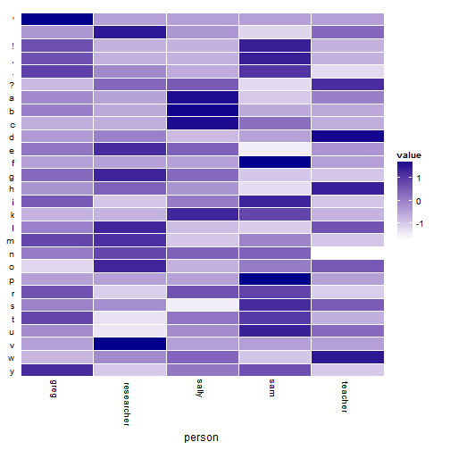

```r
plot(x)
```

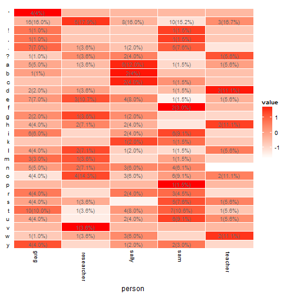

```r
plot(x, label = TRUE, high = "red", lab.digits = 1, zero.replace = "")
```

♦ **[`character_table`](http://trinker.github.io/qdap_dev/word_count.html) Additional Plotting**♦

```r
library(ggplot2);library(reshape2)
dat <- char_table(DATA$state, list(DATA$sex, DATA$adult))
dat2 <- colsplit2df(melt(dat$raw), keep.orig = TRUE)
dat2$adult2 <- lookup(as.numeric(as.character(dat2$adult)),
    c(0, 1), c("child", "adult"))
head(dat2, 15)
```

```
##    sex&adult sex adult variable value adult2
## 1        f.0   f     0        '     0  child
## 2        f.1   f     1        '     0  adult
## 3        m.0   m     0        '     4  child
## 4        m.1   m     1        '     0  adult
## 5        f.0   f     0              8  child
## 6        f.1   f     1              5  adult
## 7        m.0   m     0             26  child
## 8        m.1   m     1              3  adult
## 9        f.0   f     0        !     0  child
## 10       f.1   f     1        !     0  adult
## 11       m.0   m     0        !     2  child
## 12       m.1   m     1        !     0  adult
## 13       f.0   f     0        ,     0  child
## 14       f.1   f     1        ,     0  adult
## 15       m.0   m     0        ,     2  child
```

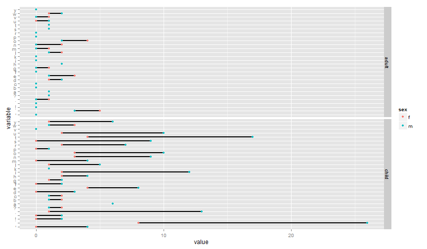

```r
ggplot(data = dat2, aes(y = variable, x = value, colour=sex)) +
    facet_grid(adult2~.) +
    geom_line(size=1, aes(group =variable), colour = "black") +
    geom_point()
```

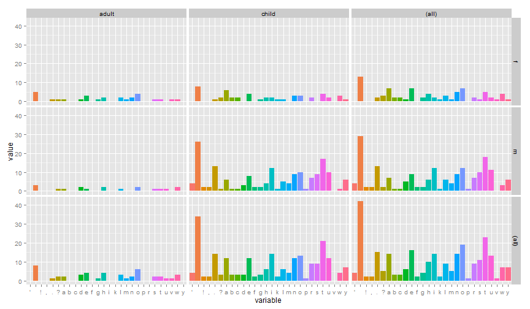

```r
ggplot(data = dat2, aes(x = variable, y = value)) +
    geom_bar(aes(fill = variable), stat = "identity") +
    facet_grid(sex ~ adult2, margins = TRUE) +
    theme(legend.position="none")
```

#### SPSS Style Frequency Tables

It is helpful to view the frequency distributions for a vector, matrix or dataframe. The [`dist_tab`](http://trinker.github.io/qdap_dev/dist_tab.html) function allows the researcher to quickly generate frequency distributions.

♦ **[`dist_tab`](http://trinker.github.io/qdap_dev/dist_tab.html) Examples**♦

```r
dist_tab(rnorm(10000), 10)
```

```
##            interval freq cum.freq percent cum.percent
## 1     (-4.13,-3.31]    4        4    0.04        0.04
## 2     (-3.31,-2.49]   63       67    0.63        0.67
## 3     (-2.49,-1.68]  405      472    4.05        4.72
## 4    (-1.68,-0.864] 1421     1893   14.21       18.93
## 5  (-0.864,-0.0483] 2899     4792   28.99       47.92
## 6   (-0.0483,0.767] 2900     7692   29.00       76.92
## 7      (0.767,1.58] 1732     9424   17.32       94.24
## 8        (1.58,2.4]  505     9929    5.05       99.29
## 9        (2.4,3.21]   66     9995    0.66       99.95
## 10      (3.21,4.04]    5    10000    0.05      100.00
```

```r
dist_tab(sample(c("red", "blue", "gray"), 100, T), right = FALSE)
```

```
##   interval freq cum.freq percent cum.percent
## 1     blue   31       31      31          31
## 2     gray   43       74      43          74
## 3      red   26      100      26         100
```

```r
dist_tab(CO2, 4)
```

```
## $Plant
##    interval freq cum.freq percent cum.percent
## 1       Qn1    7        7    8.33        8.33
## 2       Qn2    7       14    8.33       16.67
## 3       Qn3    7       21    8.33       25.00
## 4       Qc1    7       28    8.33       33.33
## 5       Qc3    7       35    8.33       41.67
## 6       Qc2    7       42    8.33       50.00
## 7       Mn3    7       49    8.33       58.33
## 8       Mn2    7       56    8.33       66.67
## 9       Mn1    7       63    8.33       75.00
## 10      Mc2    7       70    8.33       83.33
## 11      Mc3    7       77    8.33       91.67
## 12      Mc1    7       84    8.33      100.00
##
## $Type
##      interval freq cum.freq percent cum.percent
## 1      Quebec   42       42      50          50
## 2 Mississippi   42       84      50         100
##
## $Treatment
##     interval freq cum.freq percent cum.percent
## 1 nonchilled   42       42      50          50
## 2    chilled   42       84      50         100
##
## $conc
##      interval freq cum.freq percent cum.percent
## 1  (94.1,321]   36       36   42.86       42.86
## 2   (321,548]   24       60   28.57       71.43
## 3   (548,774]   12       72   14.29       85.71
## 4 (774,1e+03]   12       84   14.29      100.00
##
## $uptake
##      interval freq cum.freq percent cum.percent
## 1 (7.66,17.1]   19       19   22.62       22.62
## 2 (17.1,26.6]   18       37   21.43       44.05
## 3   (26.6,36]   25       62   29.76       73.81
## 4   (36,45.5]   22       84   26.19      100.00
```

```r
wdst <- with(mraja1spl, word_stats(dialogue, list(sex, fam.aff, died)))
dist_tab(wdst$gts[1:4], 5)
```

```
$`sex&fam.aff&died`
          interval Freq cum.Freq percent cum.percent
1      f.cap.FALSE    1        1    9.09        9.09
2       f.cap.TRUE    1        2    9.09       18.18
3      f.mont.TRUE    1        3    9.09       27.27
4      m.cap.FALSE    1        4    9.09       36.36
5       m.cap.TRUE    1        5    9.09       45.45
6    m.escal.FALSE    1        6    9.09       54.55
7     m.escal.TRUE    1        7    9.09       63.64
8     m.mont.FALSE    1        8    9.09       72.73
9      m.mont.TRUE    1        9    9.09       81.82
10    m.none.FALSE    1       10    9.09       90.91
11 none.none.FALSE    1       11    9.09      100.00

$n.sent
```

[output cut: 22 more lines]

#### Parts of Speech Tagging & Counts

In some analysis of text the research may wish to gather information about parts of speech (POS). The function [`pos`](http://trinker.github.io/qdap_dev/pos.html) and it's grouping variable counterpart, [`pos_by`](http://trinker.github.io/qdap_dev/pos.html), can provide this functionality. The [`pos`](http://trinker.github.io/qdap_dev/pos.html) functions are wrappers for POS related functions from the [openNLP](http://cran.r-project.org/web/packages/openNLP/index.html) package. The [`pos_tags`](http://trinker.github.io/qdap_dev/pos.html) function provides a quick reference to what the POS tags utilized by [openNLP](http://cran.r-project.org/web/packages/openNLP/index.html) mean. For more information on the POS tags see the [Penn Treebank Project](http://www.cis.upenn.edu/~treebank/).

The following examples utilize the [`pos_by`](http://trinker.github.io/qdap_dev/pos.html) function as the [`pos`](http://trinker.github.io/qdap_dev/pos.html) function is used identically, except without specifying a `grouping.var`. It is important to realize that POS tagging is a very slow process. The speed can be increased by using the **parallel = TRUE** argument. Additionally, the user can recycle the output from one run of [`pos`](http://trinker.github.io/qdap_dev/pos.html), [`pos_by`](http://trinker.github.io/qdap_dev/pos.html) or [`formality`](http://trinker.github.io/qdap_dev/formality.html) and use it interchangeably between the [`pos_by`](http://trinker.github.io/qdap_dev/pos.html) and [`formality`](http://trinker.github.io/qdap_dev/formality.html) functions. This reuses the POS tagging which is the time intensive part (and can be extracted via **YOUR_OUTPUT_HERE[[“POStagged”]]** from any of the above objects).

♦ **[`pos_tags`](http://trinker.github.io/qdap_dev/pos.html)** - *Interpreting POS Tags*♦

```r
pos_tags()
```

```
##    Tag  Description
## 1  CC   Coordinating conjunction
## 2  CD   Cardinal number
## 3  DT   Determiner
## 4  EX   Existential there
## 5  FW   Foreign word
## 6  IN   Preposition or subordinating conjunction
## 7  JJ   Adjective
## 8  JJR  Adjective, comparative
## 9  JJS  Adjective, superlative
## 10 LS   List item marker
## 11 MD   Modal
## 12 NN   Noun, singular or mass
## 13 NNS  Noun, plural
## 14 NNP  Proper noun, singular
```

[output cut: 22 more lines]

♦ **[`pos_by`](http://trinker.github.io/qdap_dev/pos.html)** - *POS by Group(s)*♦

```r
posbydat <- with(DATA, pos_by(state, list(adult, sex)))
## Available elements
names(posbydat)
```

```
 [1] "text"         "POStagged"    "POSprop"      "POSfreq"
 [5] "POSrnp"       "percent"      "zero.replace" "pos.by.freq"
 [9] "pos.by.prop"  "pos.by.rnp"
```

```r
## Inspecting the truncated output
lview(posbydat)
```

```
$text
[1] "computer is fun not too fun"     "no its not its dumb"
[3] "what should we do"               "you liar it stinks"
[5] "i am telling the truth"          "how can we be certain"
[7] "there is no way"                 "i distrust you"
[9] "what are you talking about"      "shall we move on good then"
[11] "im hungry lets eat you already"


$POStagged
                               POStagged                   POStags word.count
1 computer/NN is/VBZ fun/NN ...RB fun/NN   NN, VBZ, NN, RB, RB, NN          6
2 no/DT its/PRP$ not/RB its/PRP$ dumb/JJ    DT, PRP$, RB, PRP$, JJ          5
3         what/WP should/MD we/PRP do/VB           WP, MD, PRP, VB          4
4      you/PRP liar/VBP it/PRP stinks/VB         PRP, VBP, PRP, VB          4
5 i/PRP am/VBP telling/VBG...DT truth/NN     PRP, VBP, VBG, DT, NN          5
6 how/WRB can/MD we/PRP ...VB certain/JJ      WRB, MD, PRP, VB, JJ          5
7           there/EX is/VBZ no/DT way/NN           EX, VBZ, DT, NN          4
8               i/FW distrust/NN you/PRP               FW, NN, PRP          3
9  what/WP are/VBP you/PR...VBG about/IN     WP, VBP, PRP, VBG, IN          5
10 shall/MD we/PRP move/VB ...JJ then/RB   MD, PRP, VB, IN, JJ, RB          6
11 im/PRP hungry/JJ let...PRP already/RB PRP, JJ, VBZ, VB, PRP, RB          6


$POSprop
   wrd.cnt propDT propEX   propFW   propIN   propJJ   propMD ... propWRB
1        6      0      0  0.00000  0.00000  0.00000  0.00000           0
2        5     20      0  0.00000  0.00000 20.00000  0.00000           0
3        4      0      0  0.00000  0.00000  0.00000 25.00000           0
4        4      0      0  0.00000  0.00000  0.00000  0.00000           0
5        5     20      0  0.00000  0.00000  0.00000  0.00000           0
6        5      0      0  0.00000  0.00000 20.00000 20.00000          20
7        4     25     25  0.00000  0.00000  0.00000  0.00000           0
8        3      0      0 33.33333  0.00000  0.00000  0.00000           0
9        5      0      0  0.00000 20.00000  0.00000  0.00000           0
10       6      0      0  0.00000 16.66667 16.66667 16.66667           0
11       6      0      0  0.00000  0.00000 16.66667  0.00000           0

$POSfreq
   wrd.cnt DT EX FW IN JJ MD NN PRP PRP$ RB VB VBG VBP VBZ WP WRB
```

[output cut: 39 more lines]

```

$pos.by.prop
  adult&sex wrd.cnt       DT       EX       FW       IN        JJ ... WP
1       0.f      10 0.000000 0.000000 0.000000 10.00000 10.000000     10
2       0.m      33 9.090909 3.030303 3.030303  0.00000  6.060606      0
3       1.f       6 0.000000 0.000000 0.000000 16.66667 16.666667      0
4       1.m       4 0.000000 0.000000 0.000000  0.00000  0.000000     25


$pos.by.rnp
  adult&sex wrd.cnt      DT      EX      FW       IN       JJ ...       WP
1       0.f      10       0       0       0 1(10.0%) 1(10.0%)     1(10.0%)
2       0.m      33 3(9.1%) 1(3.0%) 1(3.0%)        0  2(6.1%)            0
3       1.f       6       0       0       0 1(16.7%) 1(16.7%)            0
4       1.m       4       0       0       0        0        0     1(25.0%)
```

♦ **Plot Method**♦

[figure not shown]

```r
plot(posbydat, values = TRUE, digits = 2)
```

♦ **[`pos_by`](http://trinker.github.io/qdap_dev/pos.html)** - *Recycling Saves Time*♦

```r
posbydat2 <- with(DATA, pos_by(posbydat, list(person, sex)))
system.time(with(DATA, pos_by(posbydat, list(person, sex))))
```

```
    user  system elapsed
    0.07    0.00    0.07
```

```r
## `pos_by` output Recycled for `formality`
with(DATA, formality(posbydat, list(person, sex)))
```

```
##     person&sex word.count formality
## 1        sam.m         13     34.62
## 2       greg.m         24     33.33
## 3 researcher.f          6     33.33
## 4      sally.f         10     20.00
## 5    teacher.m          4      0.00
```

#### Syllabication and Counts

Examining syllable counts can be a useful source of information in associating with education level, age, SES, gender, etc. Several readability scores rely on syllable and polysyllable word counts. qdap defines a *polysyllable* word as a word with 3 or more syllables, though some in the linguistics/literacy fields may include two syllable words. [`syllable_count`](http://trinker.github.io/qdap_dev/syllabication.html) is the base function for [`syllable_sum`](http://trinker.github.io/qdap_dev/syllabication.html), [`polysyllable_sum`](http://trinker.github.io/qdap_dev/syllabication.html), and [`combo_syllable_sum`](http://trinker.github.io/qdap_dev/syllabication.html), though is generally not of direct use to the researcher conducting discourse analysis. [`syllable_count`](http://trinker.github.io/qdap_dev/syllabication.html) uses a dictionary lookup method augmented with a syllable algorithm for words not found in the dictionary. Words not found in the dictionary are denoted with a **NF** in the **in.dictionary** column of the output.

Here is a list of qdap [`syllabication`](http://trinker.github.io/qdap_dev/syllabication.html) functions and their descriptions:

| **syllable_count** | Count the number of syllables in a single text string. |
| --- | --- |
| **syllable_sum** | Count the number of syllables per row of text. |
| **polysyllable_sum** | Count the number of polysyllables per row of text. |
| **combo_syllable_sum** | Count the number of both syllables and polysyllables per row of text. |

♦ **[`syllabication`](http://trinker.github.io/qdap_dev/syllabication.html) Examples**♦

```r
syllable_count("Robots like Dason lie.")
```

```
   words syllables in.dictionary
1 robots         2             -
2   like         1             -
3  dason         2            NF
4    lie         1             -
```

```r
## The text variable for reference
DATA$state
```

```
 [1] "Computer is fun. Not too fun."
 [2] "No it's not, it's dumb."
 [3] "What should we do?"
 [4] "You liar, it stinks!"
 [5] "I am telling the truth!"
 [6] "How can we be certain?"
 [7] "There is no way."
 [8] "I distrust you."
 [9] "What are you talking about?"
[10] "Shall we move on?  Good then."
[11] "I'm hungry.  Let's eat.  You already?"
```

```r
syllable_sum(DATA$state)
```

```
 [1] 8 5 4 5 6 6 4 4 7 6 9
```

```r
polysyllable_sum(DATA$state)
```

```
 [1] 1 0 0 0 0 0 0 0 0 0 1
```

```r
combo_syllable_sum(DATA$state)
```

```
   syllable.count polysyllable.count
1               8                  1
2               5                  0
3               4                  0
4               5                  0
5               6                  0
6               6                  0
7               4                  0
8               4                  0
9               7                  0
10              6                  0
11              9                  1
```

### Word Measures and Scoring

The following functions will be utilized in this section (click to view more):

- Readability Measures

- Dissimilarity

- Diversity Statistics

- Formality Score

- Kullback-Leibler divergence

- Polarity Score (Sentiment Analysis)

- Word Associations (Correlations)

qdap offers a number of word statistics and scores applied by grouping variable. Some functions are original to qdap, while others are taken from academic papers. Complete references for statistics/scores based on others' work are provided in the [help manual](http://cran.r-project.org/web/packages/qdap/qdap.pdf) where appropriate. It is assumed that the reader is familiar, or can become acquainted, with the theory and methods for qdap functions based on the work of others. For qdap functions that are original to qdap a more robust description of the use and theory is provided.

#### Readability Scores

Readability scores were originally designed to measure the difficulty of text. Scores are generally based on, number of words, syllables, polly-syllables and word length. While these scores are not specifically designed for, or tested on, speech, they can be useful indicators of speech complexity. The following score examples demonstrate the use of the following readability scores:

1. Automated Readability Index
2. Coleman Liau
3. SMOG
4. Flesch Kincaid
5. Fry
6. Linsear Write

♦ **Automated Readability Index**♦

```r
with(rajSPLIT, automated_readability_index(dialogue, list(sex, fam.aff)))
```

```
  sex&fam.aff word.count sentence.count character.count Aut._Read._Index
1       f.cap       9458            929           37474              2.3
2      f.mont         28              4              88             -3.1
3       m.cap       1204            133            4615              1.2
4     m.escal       3292            262           13406              4.0
5      m.mont       6356            555           26025              3.6
6      m.none       3233            250           13527              4.7
7   none.none        156             12             665              5.1
```

♦ **Coleman Liau**♦

```r
with(rajSPLIT, coleman_liau(dialogue, list(fam.aff, act)))
```

```
  fam.aff&act word.count sentence.count character.count Coleman_Liau
1       cap.1       2636            272           10228          4.0
2       cap.2       2113            193            8223          4.4
3       cap.3       3540            339           14183          4.9
4       cap.4       2159            232            8620          4.5
5       cap.5        214             26             835          3.5
6     escal.1        748             36            3259          8.4
```

♦ **SMOG**♦

```r
with(rajSPLIT, SMOG(dialogue, list(person, act)))
```

```
         person&act word.count sentence.count polysyllable.count SMOG
1        Benvolio.1        621             51                 25  7.1
2         Capulet.1        736             72                 35  7.1
3         Capulet.3        749             69                 28  6.8
4         Capulet.4        569             73                 25  6.5
5  Friar Laurence.2        699             42                 36  8.4
6  Friar Laurence.3        675             61                 32  7.3
7  Friar Laurence.4        656             42                 25  7.5
8  Friar Laurence.5        696             54                 32  7.5
9          Juliet.2       1289            113                 48  6.9
10         Juliet.3       1722            152                 64  6.8
11         Juliet.4        932             61                 37  7.6
12   Lady Capulet.3        393             39                 15  6.7
13       Mercutio.2        964             82                 43  7.3
14       Mercutio.3        578             54                 19  6.5
15          Nurse.1        599             59                 20  6.5
16          Nurse.2        779             76                 24  6.3
17          Nurse.3        579             68                 14  5.7
18          Nurse.4        250             50                  9  5.6
19          Romeo.1       1158            113                 48  6.9
20          Romeo.2       1289            109                 46  6.8
21          Romeo.3        969             87                 48  7.4
22          Romeo.5       1216            103                 52  7.2
```

♦ **Flesch Kincaid**♦

```r
with(rajSPLIT, flesch_kincaid(dialogue, list(sex, fam.aff)))
```

```
  sex&fam.aff word.count sentence.count syllable.count FK_grd.lvl FK_read.ease
1       f.cap       9458            929          11641        2.9       92.375
2      f.mont         28              4             30       -0.2      109.087
3       m.cap       1204            133           1452        2.2       95.621
4     m.escal       3292            262           4139        4.1       87.715
5      m.mont       6356            555           7965        3.7       89.195
6      m.none       3233            250           4097        4.4       86.500
7   none.none        156             12            195        4.2       87.890
```

Note that the Fry score is a graphical display, rather than text as the other readability scores are. This is in keeping with the original procedures outlined by Fry.

♦ **Fry**♦

```r
with(rajSPLIT, fry(dialogue, list(sex, fam.aff)))
```

```
##   sex&fam.aff ave.syll.per.100 ave.sent.per.100
## 1       f.cap          123.000            8.728
## 2       m.cap          115.333           13.190
## 3     m.escal          127.000            9.824
## 4      m.mont          122.000           11.642
## 5      m.none          123.000            8.107
```

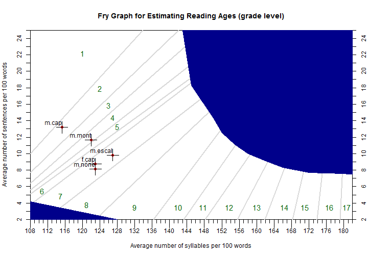

♦ **Linsear Write**♦

```r
with(rajSPLIT, linsear_write(dialogue, person))
```

```
           person sent.per.100 hard_easy_sum Linsear_Write
1       Balthasar        9.556           110          4.76
2        Benvolio        4.143           108         12.03
3         Capulet       11.469           115          4.01
4          Chorus        3.071           104         15.93
5  First Watchman       14.222           114          3.01
6  Friar Laurence        4.263           108         11.67
7         Gregory       11.000           100          3.55
8          Juliet        3.446           110         14.96
9    Lady Capulet        7.267           110          6.57
10       Mercutio        5.625           102          8.07
11       Montague        6.000           114          8.50
12          Nurse       12.098           102          3.22
13          Paris        9.091           110          5.05
14          Peter       10.357           110          4.31
15         Prince       10.842           110          4.07
16          Romeo        9.250           114          5.16
17        Sampson        9.421           107          4.68
18        Servant        9.667           104          4.38
19         Tybalt        9.591           112          4.84
```

#### Dissimilarity

*Dissimilarity* is another term for distance that is often used in text analysis to measure the pairwise proximity of grouping variables. The qdap [`Dissimilarity`](http://trinker.github.io/qdap_dev/Dissimilarity.html) function is a wrapper for the R stats package's [dist](http://stat.ethz.ch/R-manual/R-devel/library/stats/html/dist.html) function designed to handle text. [`Dissimilarity`](http://trinker.github.io/qdap_dev/Dissimilarity.html) takes all the same **method** types as [dist](http://stat.ethz.ch/R-manual/R-devel/library/stats/html/dist.html) but also includes the default **method = “prop”** (1 - “binary”) that is focused on the similarity between grouping variables.

♦ **[`Dissimilarity`](http://trinker.github.io/qdap_dev/Dissimilarity.html) Examples**♦

```r
with(DATA, Dissimilarity(state, list(sex, adult)))
```

```
      f.0   f.1   m.0
f.1 0.067
m.0 0.029 0.000
m.1 0.167 0.111 0.000
```

```r
with(DATA, Dissimilarity(state, person))
```

```
            greg researcher sally   sam
researcher 0.000
sally      0.037      0.067
sam        0.160      0.000 0.050
teacher    0.000      0.111 0.167 0.000
```

```r
with(DATA, Dissimilarity(state, person, method = "minkowski"))
```

```
            greg researcher sally   sam
researcher 5.477
sally      5.657      3.742
sam        5.568      4.796 4.796
teacher    5.292      2.828 3.162 4.583
```

```r
dat <- pres_debates2012[pres_debates2012$person %in% qcv(OBAMA, ROMNEY),]
with(dat, Dissimilarity(dialogue, list(person, time)))
```

```
         OBAMA.1 OBAMA.2 OBAMA.3 ROMNEY.1 ROMNEY.2
OBAMA.2    0.340
OBAMA.3    0.300   0.341
ROMNEY.1   0.340   0.287   0.258
ROMNEY.2   0.291   0.349   0.296    0.321
ROMNEY.3   0.264   0.297   0.329    0.290    0.338
```

♦ **[`Dissimilarity`](http://trinker.github.io/qdap_dev/Dissimilarity.html) Clustering (Dendrogram)**♦

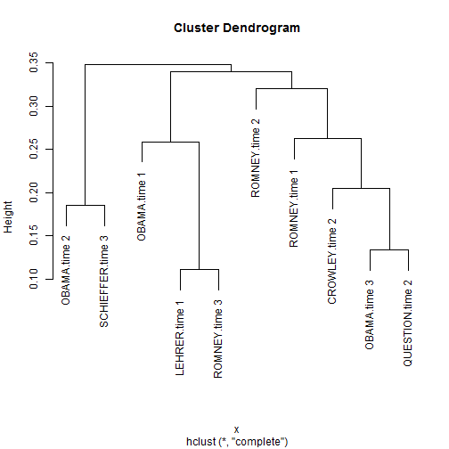

```r
x <- with(pres_debates2012, Dissimilarity(dialogue, list(person, time)))
fit <- hclust(x)
plot(fit)
```

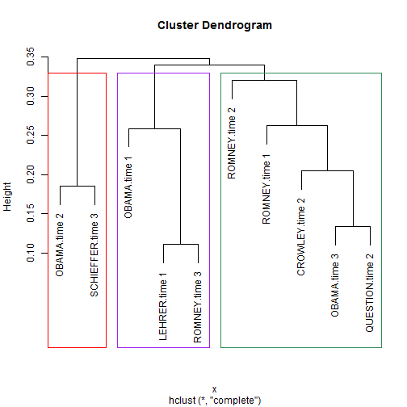

```r
## draw dendogram with colored borders around the 3 clusters
rect.hclust(fit, k=3, border=c("red", "purple", "seagreen"))
```

#### Kullback-Leibler divergence

The Kullback Leibler is often used as a measure of distance, though the matrix is asymmetrical. qdap's [`kullback_leibler`](http://trinker.github.io/qdap_dev/kullback_leibler.html) compares the differences between two probability distributions and often leads to results similar to those from [`Dissimilarity`](http://trinker.github.io/qdap_dev/Dissimilarity.html). Note that unlike many other qdap functions the user must either supply a word frequency matric ([`wfm`](http://trinker.github.io/qdap_dev/Word_Frequency_Matrix.html)) to **x** or some other matrix format. This allows the function to be flexibly used with [`termco`](http://trinker.github.io/qdap_dev/termco.html) and other functions that produce count matrices.

♦ **[`kullback_leibler`](http://trinker.github.io/qdap_dev/kullback_leibler.html) Example** - *Compare to [`Dissimilarity`](http://trinker.github.io/qdap_dev/Dissimilarity.html)*♦

```r
dat <- pres_debates2012[pres_debates2012$person %in% qcv(OBAMA, ROMNEY),]
(KL <- (kullback_leibler(with(dat, wfm(dialogue, list(person, time))))))
```

```
         OBAMA.1 OBAMA.2 OBAMA.3 ROMNEY.1 ROMNEY.2 ROMNEY.3
OBAMA.1    0.000   0.237   0.221    0.195    0.250    0.264
OBAMA.2    0.104   0.000   0.161    0.148    0.142    0.223
OBAMA.3    0.119   0.152   0.000    0.142    0.180    0.168
ROMNEY.1   0.207   0.297   0.279    0.000    0.216    0.224
ROMNEY.2   0.194   0.195   0.262    0.116    0.000    0.234
ROMNEY.3   0.160   0.182   0.141    0.101    0.140    0.000
```

[figure not shown]

```r
plot(KL, high = "red", values = TRUE)
```

#### Diversity Statistics

Diversity, as applied to dialogue, is a measure of the richness of language being used. Specifically, it measures how expansive the vocabulary is while taking into account the number of total words used and the different words being used. qdap's [`diversity`](http://trinker.github.io/qdap_dev/diversity.html) function provides output for the Simpson, Shannon, Collision, Berger Parker, and Brillouin measures.

♦ **[`diversity`](http://trinker.github.io/qdap_dev/diversity.html) Example**♦

```r
(div.mod <- with(mraja1spl, diversity(dialogue, person)))
```

[output not shown]

♦ **[`diversity`](http://trinker.github.io/qdap_dev/diversity.html) Plot Method**♦

```r
plot(div.mod, low = "yellow", grid = FALSE, values = TRUE)
```

[output not shown]

#### Formality

\[ F = 50(\frac{n_{f}-n_{c}}{N} + 1) \]

Where:

\[ f = \left \{noun, \;adjective, \;preposition, \;article\right \} \] \[ c = \left \{pronoun, \;verb, \;adverb, \;interjection\right \} \] \[ N = \sum{(f \;+ \;c \;+ \;conjunctions)} \]

Note that formality utilize parts of speech tagging. This is computationally expensive. The user may gain speed by setting **parallel = TRUE** if multiple cores are available. The user can also “recycle” the output from [`pos`](http://trinker.github.io/qdap_dev/pos.html), [`pos_by`](http://trinker.github.io/qdap_dev/pos.html), or [`formality`](http://trinker.github.io/qdap_dev/formality.html) for the same text. This save considerable time as the parts of speech is saved in the output from these functions as demonstrated in the Recycled Formality Example below.

[`formality`](http://trinker.github.io/qdap_dev/formality.html) also has a plotting method that allows for easy visualization and comparison of formality scores, word counts, formal/contextual parts of speech all by grouping variable(s). Please note that Heylighen & Dewaele (2002) state, “At present, a sample would probably need to contain a few hundred words for the measure to be minimally reliable. For single sentences, the F-value should only be computed for purposes of illustration” (p. 24).

♦ **[`formality`](http://trinker.github.io/qdap_dev/formality.html) Example**♦

```r
form <- with(raj, formality(dialogue, person))
```

♦ **[`formality`](http://trinker.github.io/qdap_dev/formality.html) Plot Method**♦

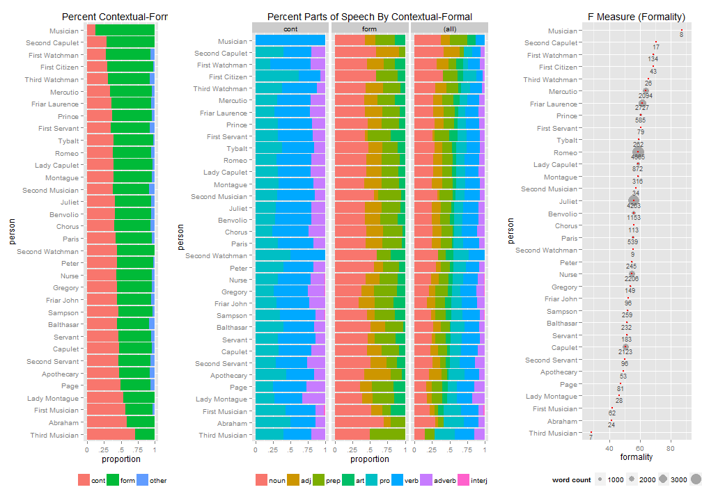

```r
plot(form)
```

♦ **Recycling [`formality`](http://trinker.github.io/qdap_dev/formality.html)**♦

```r
(form2 <- with(raj, formality(form, act)))
```

```
  act word.count formality
1   5       3379     58.38
2   2       5358     58.10
3   1       5525     57.59
4   3       6354     57.22
5   4       3167     55.89
```

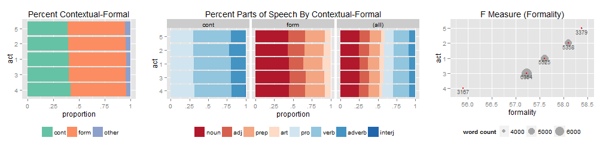

```r
plot(form2, bar.colors=c("Set2", "RdBu"))
```

#### Polarity Score (Sentiment Analysis)

Polarity assignment, a form of sentiment analysis, is using an algorithm to determine the polarity of a sentence/statement. While the use polarity scores is applied to many forms of written social dialogue (e.g., Twitter, Facebook, etc.) it has not typically been applied to spoken dialogue. qdap offers a flexible function, [`polarity`](http://trinker.github.io/qdap_dev/polarity.html) to determine polarity at the sentence level as well as to assign an average polarity score to individual groups within the grouping variable(s). The frame work for [`polarity`](http://trinker.github.io/qdap_dev/polarity.html) is flexible in that the user may supply a polarized dictionary and optional weights. Many dictionaries used in sentiment analysis are designed for written, adult, online interaction.

It is assumed you have run sentSplit on the data.  
If this is not the case the counts will not be accurate.

The polarity score generated by [`polarity`](http://trinker.github.io/qdap_dev/polarity.html) is dependent upon the polarity dictionary used. This function defaults to the word polarity dictionary used by [Hu & Liu (2004)](http://www.cs.uic.edu/~liub/FBS/sentiment-analysis.html), however, this may not be appropriate for the context of children in a classroom. For instance the word “sick” in a high school setting may mean that something is good, whereas “sick” used by a typical adult indicates something is not right or negative connotation. The user may (is encouraged) to provide/augment/alter the dictionary (see the [`sentiment_frame`](http://trinker.github.io/qdap_dev/polarity.html) function). Development of context specific dictionaries, that are better suited for spoken dialogue in a school setting, is an exciting prospect that could lead to greater understanding of the emotional aspects of the spoken word on students. The user may add a dictionary with optional weights as a dataframe within an environment. The [`sentiment_frame`](http://trinker.github.io/qdap_dev/polarity.html) function aides the user in creating the polarity environment.

The equation used by the algorithm to assign value to polarity of each sentence fist utilizes the sentiment dictionary (Hu & Liu, 2004) to tag polarized words. A context cluster of words is pulled from around this polarized word (default 4 words before and two words after) to be considered as valence shifters. The words in this context cluster are tagged as neutral (\(x_i^{0}\)), negator (\(x_i^{N}\)), amplifier (\(x_i^{a}\)), or de-amplifier (\(x_i^{d}\)). Neutral words hold no value in the equation but do affect word count (\(n\)). Each polarized word is then weighted \(w\) based on the weights from the **polarity.frame** argument and then further weighted by the number and position of the valence shifters directly surrounding the positive or negative word. The researcher may provide a weight \(c\) to be utilized with amplifiers/de-amplifiers (default is .8; deamplifier weight is constrained to -1 lower bound). Last, these context cluster (\(x_i^{T}\)) are summed and divided by the square root of the word count (\(\sqrt{n}\)) yielding an unbounded polarity score (\(\delta\)). Note that context clusters containing a comma before the polarized word will only consider words found after the comma.

\[ \delta=\frac{x_i^T}{\sqrt{n}} \]

Where:

\[ x_i^T=\sum{((1 + c(x_i^{A} - x_i^{D}))\cdot w(-1)^{\sum{x_i^{N}}})} \]  
\[ x_i^{A}=\sum{(w_{neg}\cdot x_i^{a})} \]  
\[ x_i^D = \max(x_i^{D'}, -1) \]  
\[ x_i^{D'}=\sum{(- w_{neg}\cdot x_i^{a} + x_i^{d})} \]  
\[ w_{neg}= \left(\sum{x_i^{N}}\right) \bmod {2} \]

The following examples demonstrate how the [`polarity`](http://trinker.github.io/qdap_dev/polarity.html) and [`sentiment_frame`](http://trinker.github.io/qdap_dev/polarity.html) functions operate. Here the polarity for the [`mraja1spl`](http://trinker.github.io/qdap_dev/mraja1spl.html) data set (Act 1 of Romeo and Juliet). The gender, family affiliation and binary died/didn't die are used as the grouping variables.

♦ **[`polarity`](http://trinker.github.io/qdap_dev/polarity.html) Example**♦

```r
 (poldat <- with(mraja1spl, polarity(dialogue, list(sex, fam.aff, died))))
```

```
POLARITY BY GROUP
=================

   sex&fam.aff&died tot.sent tot.word ave.polarity sd.polarity sd.mean.polarity
1       f.cap.FALSE      158     1810        0.076       0.262            0.292
2        f.cap.TRUE       24      221        0.042       0.209            0.204
3       f.mont.TRUE        4       29        0.079       0.398            0.199
4       m.cap.FALSE       73      717        0.026       0.256            0.104
5        m.cap.TRUE       17      185       -0.160       0.313           -0.510
6     m.escal.FALSE        9      195       -0.153       0.313           -0.488
7      m.escal.TRUE       27      646       -0.069       0.256           -0.272
8      m.mont.FALSE       70      952       -0.044       0.384           -0.114
9       m.mont.TRUE      114     1273       -0.004       0.409           -0.009
10     m.none.FALSE        7       78        0.062       0.107            0.583
11  none.none.FALSE        5       18       -0.282       0.439           -0.642
```

```r
names(poldat)
```

```
## [1] "all"    "group"  "digits"
```

♦ **[`polarity`](http://trinker.github.io/qdap_dev/polarity.html)** - *Sentence Level Polarity Scores*♦

```r
htruncdf(counts(poldat), 20, 10)
```

```
##    sex&fam.af wc   polarity pos.words  neg.words   text.var
## 1  m.cap.FALS 10          0         -          - Gregory, o
## 2  m.cap.FALS  8          0         -          - No, for th
## 3  m.cap.FALS 11          0         -          - I mean, an
## 4  m.cap.FALS 13          0         -          - Ay, while
## 5  m.cap.FALS  6 -0.4082482         -     strike I strike q
## 6  m.cap.FALS  8 0.35355339         -     strike But thou a
## 7  m.cap.FALS  9          0         -          - A dog of t
## 8  m.cap.FALS 12 0.28867513   valiant          - To move is
## 9  m.cap.FALS 10          0         -          - therefore,
## 10 m.cap.FALS 10          0         -          - A dog of t
## 11 m.cap.FALS 12          0         -          - I will tak
## 12 m.cap.FALS 13 -0.5547001         - c("weak",  That shows
## 13 m.cap.FALS 16      -0.25         -     weaker True; and
## 14 m.cap.FALS 17          0         -          - therefore
## 15 m.cap.FALS 10          0   masters    quarrel The quarre
## 16 m.cap.FALS 10 -0.3162277         -     tyrant 'Tis all o
## 17 m.cap.FALS 21 -0.2182178         -      cruel when I hav
## 18 m.cap.FALS  5          0         -          - The heads
## 19 m.cap.FALS 18 -0.2357022         -       wilt Ay, the he
## 20 m.cap.FALS  9          0         -          - They must
```

♦ **[`polarity`](http://trinker.github.io/qdap_dev/polarity.html) Plot Method**♦

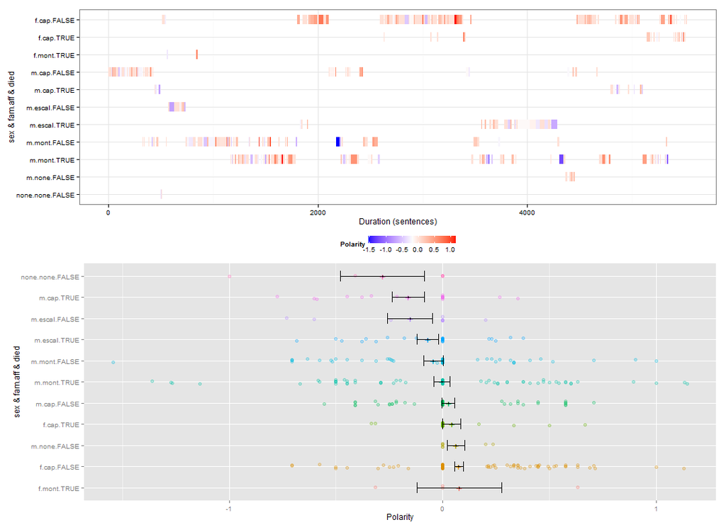

```r
plot(poldat)
```

♦ **[`polarity`](http://trinker.github.io/qdap_dev/polarity.html) Plot Group Polarity as Heat Map**♦

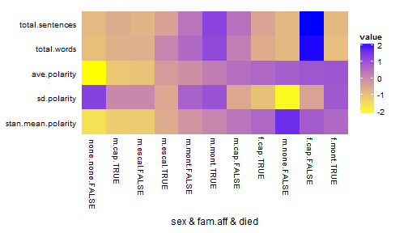

```r
qheat(scores(poldat), high="blue", low="yellow", grid=NULL, order.b="ave.polarity")
```

♦ **[`sentiment_frame`](http://trinker.github.io/qdap_dev/sentiment_frame.html)** - *Specify Your Own Polarity Environment*♦

```r
(POLENV <- sentiment_frame(positive.words, negative.words))
```

```
               x  y
   1:     a plus  1
   2:   abnormal -1
   3:    abolish -1
   4: abominable -1
   5: abominably -1
  ---
6775:  zealously -1
6776:     zenith  1
6777:       zest  1
6778:      zippy  1
6779:     zombie -1
```

♦ **Polarity Over Time** ♦

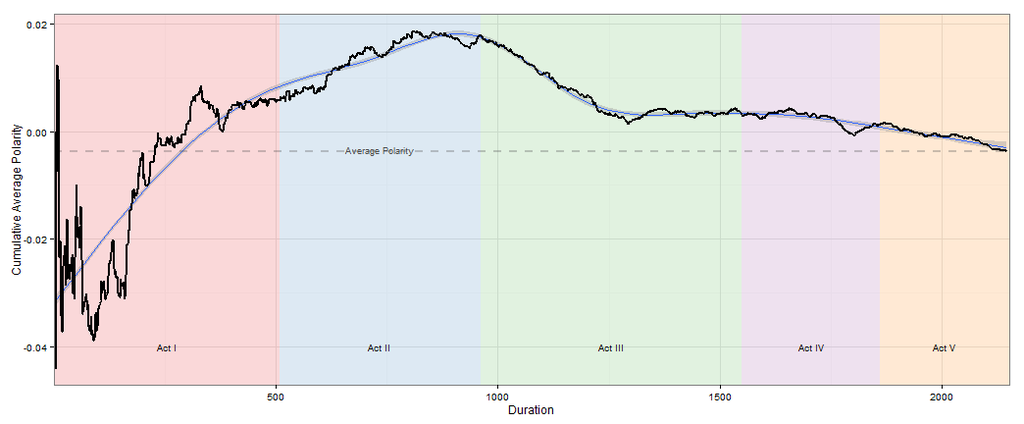

```r
poldat4 <- with(rajSPLIT, polarity(dialogue, act, constrain = TRUE))

polcount <- na.omit(counts(poldat4)$polarity)
len <- length(polcount)

cummean <- function(x){cumsum(x)/seq_along(x)}

cumpolarity <- data.frame(cum_mean = cummean(polcount), Time=1:len)

## Calculate background rectangles
ends <- cumsum(rle(counts(poldat4)$act)$lengths)
starts <- c(1, head(ends + 1, -1))
rects <- data.frame(xstart = starts, xend = ends + 1,
    Act = c("I", "II", "III", "IV", "V"))

library(ggplot2)
ggplot() + theme_bw() +
    geom_rect(data = rects, aes(xmin = xstart, xmax = xend,
        ymin = -Inf, ymax = Inf, fill = Act), alpha = 0.17) +
    geom_smooth(data = cumpolarity, aes(y=cum_mean, x = Time)) +
    geom_hline(y=mean(polcount), color="grey30", size=1, alpha=.3, linetype=2) +
    annotate("text", x = mean(ends[1:2]), y = mean(polcount), color="grey30",
        label = "Average Polarity", vjust = .3, size=3) +
    geom_line(data = cumpolarity, aes(y=cum_mean, x = Time), size=1) +
    ylab("Cumulative Average Polarity") + xlab("Duration") +
    scale_x_continuous(expand = c(0,0)) +
    geom_text(data=rects, aes(x=(xstart + xend)/2, y=-.04,
        label=paste("Act", Act)), size=3) +
    guides(fill=FALSE) +
    scale_fill_brewer(palette="Set1")
```

#### Word Association (Correlations)

It is helpful to finds words associated (or negatively associated) with or correlations between selected words in understanding language selection. The [`word_cor`](http://trinker.github.io/qdap_dev/word_cor.html) function calculates correlations (based on the [`wfm`](http://trinker.github.io/qdap_dev/wfm.html) function) for words nested within grouping variables (turn of talk is an obvious choice for a grouping variable). Running bootstrapping with a random sample can help the researcher determine if a co-occurrence of words is by chance. [`wordword_cor`](http://trinker.github.io/qdap_dev/wordword_cor.html) is even more flexible in that it can actually take a frequency matrix (e.g., the [`wfm_combine`](http://trinker.github.io/qdap_dev/wfm.html) function or the cm_ family of functions).

♦ **[`word_cor`](http://trinker.github.io/qdap_dev/word_cor.html)** - *Single Words*♦

```r
library(reports)
x <- factor(with(rajSPLIT, paste(act, pad(TOT(tot)), sep = "|")))
word_cor(rajSPLIT$dialogue, x, "romeo", .45)
```

```
$romeo
     that    tybalt
0.4540979 0.4831937
```

```r
word_cor(rajSPLIT$dialogue, x, "love", .5)
```

```
$love
 likewise
0.5013104
```

♦ **[`word_cor`](http://trinker.github.io/qdap_dev/word_cor.html)** - *Negative Correlation*♦

```r
word_cor(rajSPLIT$dialogue, x, "you", -.1)
with(rajSPLIT, word_cor(dialogue, list(person, act), "hate"))
```

[output not shown]

```
$hate
 eyesight    knight    prison    smooth     vex'd
0.7318131 0.7318131 0.7318131 0.7318131 0.7318131
```

♦ **[`word_cor`](http://trinker.github.io/qdap_dev/word_cor.html)** - *Multiple Words*♦

```r
words <- c("hate", "i", "love", "ghost")
with(rajSPLIT, word_cor(dialogue, x, words, r = .5))
```

```
$hate
          beasts        beseeming            bills             bred
       0.6251743        0.6251743        0.6251743        0.6251743
        canker'd      capulethold            clubs           coward
       0.6251743        0.6251743        0.6251743        0.6251743
          crutch        disturb'd       flourishes        fountains
       0.6251743        0.6251743        0.6251743        0.6251743
         issuing      mistemper'd neighbourstained        partisans
       0.6251743        0.6251743        0.6251743        0.6251743
      pernicious        profaners           purple       rebellious
       0.6251743        0.6251743        0.6251743        0.6251743
         streets         subjects            sword           thrice
       0.5027573        0.6251743        0.6164718        0.6251743
           throw            wield
       0.6251743        0.6251743

$i
      and      have        me        my      thee        to
0.5150992 0.5573359 0.5329341 0.5134372 0.5101593 0.5533506

$love
 likewise
0.5013104

$ghost
     bone    brains      club      dash     drink      keys kinsman's  methinks
0.7056134 0.7056134 1.0000000 1.0000000 0.5749090 1.0000000 1.0000000 0.5749090
     rage  rapier's   seeking    spices      spit
0.5749090 1.0000000 1.0000000 1.0000000 1.0000000
```

♦ **[`word_cor`](http://trinker.github.io/qdap_dev/word_cor.html)** - *Correlations Between Terms: Example 1*♦

```r
## Set r = NULL to get matrix between words
with(rajSPLIT, word_cor(dialogue, x, words, r = NULL))
```

```
             hate          i        love       ghost
hate   1.00000000 0.05142236  0.15871966 -0.01159382
i      0.05142236 1.00000000  0.36986172  0.01489943
love   0.15871966 0.36986172  1.00000000 -0.02847837
ghost -0.01159382 0.01489943 -0.02847837  1.00000000
```

♦ **[`word_cor`](http://trinker.github.io/qdap_dev/word_cor.html)** - *Correlations Between Terms: Example 2*♦

```r
dat <- pres_debates2012
dat$TOT <- factor(with(dat, paste(time, pad(TOT(tot)), sep = "|")))
dat <- dat[dat$person %in% qcv(OBAMA, ROMNEY), ]
dat$person <- factor(dat$person)
dat.split <- with(dat, split(dat, list(person, time)))

wrds <- qcv(america, debt, dollar, people, tax, health)
lapply(dat.split, function(x) {
    word_cor(x[, "dialogue"], x[, "TOT"], wrds, r=NULL)
})
```

```
$`OBAMA.time 1`
             america       dollar    people          tax      health
america  1.000000000 -0.005979775 0.6117618 -0.005979775  0.13803797
dollar  -0.005979775  1.000000000 0.1650493 -0.004219409 -0.01092353
people   0.611761819  0.165049280 1.0000000  0.165049280  0.50398555
tax     -0.005979775 -0.004219409 0.1650493  1.000000000  0.20572642
health   0.138037974 -0.010923527 0.5039855  0.205726420  1.00000000

$`ROMNEY.time 1`
           america     dollar    people         tax      health
america 1.00000000 0.07493271 0.2336551  0.07033784  0.14986684
dollar  0.07493271 1.00000000 0.5859944  0.11109650  0.33821359
people  0.23365513 0.58599441 1.0000000  0.20584588  0.61333714
tax     0.07033784 0.11109650 0.2058459  1.00000000 -0.01723713
health  0.14986684 0.33821359 0.6133371 -0.01723713  1.00000000

$`OBAMA.time 2`
            america      dollar     people        tax      health
america  1.00000000 -0.01526328 0.41353310 0.07609871  0.25733977
dollar  -0.01526328  1.00000000 0.11671525 0.51222872 -0.01220067
people   0.41353310  0.11671525 1.00000000 0.03761852  0.11285926
tax      0.07609871  0.51222872 0.03761852 1.00000000  0.03431397
health   0.25733977 -0.01220067 0.11285926 0.03431397  1.00000000

$`ROMNEY.time 2`
            america         debt     dollar     people          tax
america  1.00000000 -0.018370290 0.07531545 0.59403781  0.291238391
debt    -0.01837029  1.000000000 0.53340505 0.02329285 -0.009432552
dollar   0.07531545  0.533405053 1.00000000 0.33346752  0.600125943
people   0.59403781  0.023292854 0.33346752 1.00000000  0.516577197
tax      0.29123839 -0.009432552 0.60012594 0.51657720  1.000000000
health   0.06384509 -0.008308652 0.68299026 0.25536510  0.658231340
              health
america  0.063845090
debt    -0.008308652
dollar   0.682990261
people   0.255365102
tax      0.658231340
health   1.000000000

$`OBAMA.time 3`
            america        debt      dollar    people         tax
america  1.00000000 -0.01224452 -0.02326653 0.1182189 -0.02326653
debt    -0.01224452  1.00000000  0.37361771 0.1765301  0.75525297
dollar  -0.02326653  0.37361771  1.00000000 0.1909401  0.70993297
people   0.11821887  0.17653013  0.19094008 1.0000000  0.19094008
tax     -0.02326653  0.75525297  0.70993297 0.1909401  1.00000000

$`ROMNEY.time 3`
          america      debt    dollar    people
america 1.0000000 0.2130341 0.2675978 0.3007027
debt    0.2130341 1.0000000 0.8191341 0.4275521
dollar  0.2675978 0.8191341 1.0000000 0.4666635
people  0.3007027 0.4275521 0.4666635 1.0000000
```

♦ **[`word_cor`](http://trinker.github.io/qdap_dev/word_cor.html)** - *Matrix from [`wfm_combine`](http://trinker.github.io/qdap_dev/wfm.html)*♦

```r
worlis <- list(
    pronouns = c("you", "it", "it's", "we", "i'm", "i"),
    negative = qcv(no, dumb, distrust, not, stinks),
    literacy = qcv(computer, talking, telling)
)
y <- wfdf(DATA$state, id(DATA, prefix = TRUE))
z <- wfm_combine(y, worlis)

word_cor(t(z), word = c(names(worlis), "else.words"), r = NULL)
```

```
             pronouns   negative   literacy else.words
pronouns    1.0000000  0.2488822 -0.4407045 -0.5914760
negative    0.2488822  1.0000000 -0.2105380 -0.7146856
literacy   -0.4407045 -0.2105380  1.0000000  0.2318694
else.words -0.5914760 -0.7146856  0.2318694  1.0000000
```

### Visualizing Discourse Data

The following functions will be utilized in this section (click to view more):

- Lexical Dispersion Plot

- Word Cloud

- Gantt Plot

- Quick Heatmap

- Rank Frequency Plot

- Visualize Word Length by Turn of Talk

- Venn Diagram

- Word Network Plot

qdap offers a number of plot methods for various outputs from functions (use **plot(qdap_FUNCTION_OUTPUT)**). In addition to the numerous plot methods qdap also has several functions dedicated solely to plotting purposes. Many of these functions rely on the [ggplot2 package](http://docs.ggplot2.org/current/) (Wickham, 2009) to produce plots.

#### Lexical Dispersion Plot

The *lexical dispersion plot* is a useful tool (particularly in the early stage of analysis) for looking at the dispersion of a word throughout the dialogue. [`dispersion_plot`](http://trinker.github.io/qdap_dev/dispersion_plot.html) provides the means to look at and compare multiple word dispersions across repeated measures and/or grouping variables. This can be useful in conjunction with a correlation analysis.

The search mechanism used by [`dispersion_plot`](http://trinker.github.io/qdap_dev/dispersion_plot.html) is identical to [`termco`](http://trinker.github.io/qdap_dev/termco.html) and [`term_match`](http://trinker.github.io/qdap_dev/termco.html). For example, **“ love ”** will not yield the same search as **“love”**. The search example below demonstrates the way the search functions. For more information see the termco search description above.

♦ **[`dispersion_plot`](http://trinker.github.io/qdap_dev/dispersion_plot.html)** - *Understand the Search*♦

```r
term_match(raj$dialogue, c(" love ", "love", " night ", "night"))
```

```
$` love `
[1] "love"

$love
 [1] "love"           "love's"         "lovers"         "loved"          "lovely"
 [6] "lovest"         "lover"          "beloved"        "loves"          "newbeloved"
[11] "glove"          "lovesong"       "lovedevouring"  "loveperforming" "dearloved"

$` night `
[1] "night"

$night
[1] "night"       "fortnight"   "nights"      "tonight"     "night's"     "knight"
[7] "nightingale" "nightly"     "yesternight"
```

♦ **[`dispersion_plot`](http://trinker.github.io/qdap_dev/dispersion_plot.html)** - *Example 1*♦

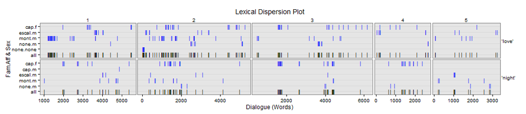

```r
with(rajSPLIT , dispersion_plot(dialogue, c("love", "night"),
    grouping.var = list(fam.aff, sex), rm.vars = act))
```

♦ **[`dispersion_plot`](http://trinker.github.io/qdap_dev/dispersion_plot.html)** - *Example 2: Color Schemes*♦

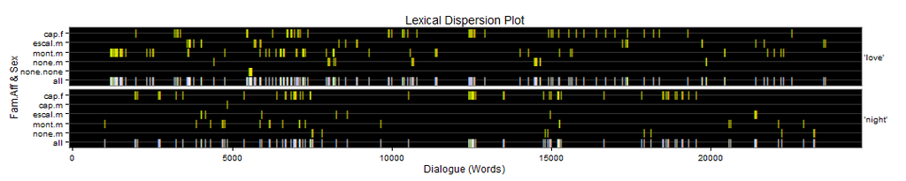

```r
with(rajSPLIT, dispersion_plot(dialogue, c("love", "night"),
    bg.color = "black", grouping.var = list(fam.aff, sex),
    color = "yellow", total.color = "white", horiz.color="grey20"))
```

Using [`dispersion_plot`](http://trinker.github.io/qdap_dev/dispersion_plot.html) with [`freq_terms`](http://trinker.github.io/qdap_dev/freq_terms.html)'s **[[“rfswl”]][[“all”]]** can be a useful means of viewing the dispersion of high frequency words after stopword removal.

♦ **[`dispersion_plot`](http://trinker.github.io/qdap_dev/dispersion_plot.html)** - *Example 3: Using with [`freq_terms`](http://trinker.github.io/qdap_dev/freq_terms.html)*♦

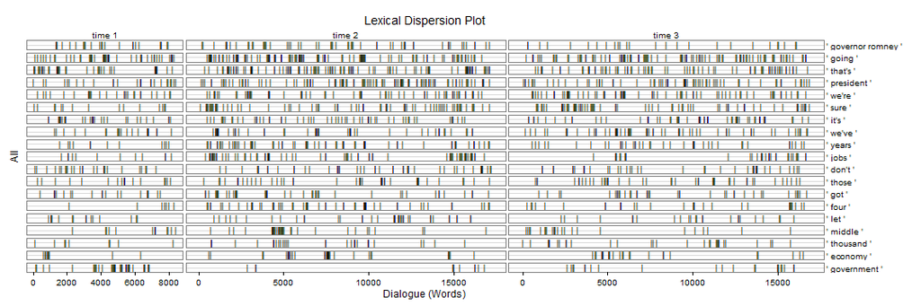

```r
wrds <- freq_terms(pres_debates2012$dialogue, stopwords = Top200Words)

## Add leading/trailing spaces if desired
wrds2 <- spaste(wrds)

## Use `~~` to maintain spaces
wrds2 <- c(" governor~~romney ", wrds2[-c(3, 12)])

## Plot
with(pres_debates2012 , dispersion_plot(dialogue, wrds2, rm.vars = time,
    color="black", bg.color="white"))
```

#### Word Clouds

Wordclouds can be a useful tool to help find words/phrases that are used frequently. It allows for the entire dialogue to be contained in pictorial form. The word cloud becomes more useful in discovering themes when color can be used in a meaningful way (i.e., the information contained in the word size and word color are not redundant). qdap has two word cloud functions (both are wrappers for [wordcloud](http://cran.r-project.org/web/packages/wordcloud/index.html) from the wordcloud package). The [`trans_cloud`](http://trinker.github.io/qdap_dev/trans_cloud.html) function produces word clouds with optional theme coloring by grouping variable. The [`gradient_cloud`](http://trinker.github.io/qdap_dev/gradient_cloud.html) function produces a gradient word cloud colored by a binary grouping variable.

[`trans_cloud`](http://trinker.github.io/qdap_dev/trans_cloud.html) is passed a list of named vectors to **target.words** in much the same way as **match.list** in [`termco`](http://trinker.github.io/qdap_dev/termco.html).

*Format for Named Vectors*

```
list(
    theme_1 = c("word1", "word2", "word3"),
    theme_2 = c("word4", "word5"),
    theme_3 = c("word6", "word7", "word8")
)
```

The **cloud.colors** argument takes a single color or a vector of colors 1 greater than the number of vectors of **target.words**. The order of **cloud.colors** corresponds to the order of **target.words** with the extra, final color being utilized for all words not matched to **target.words**.

♦ **[`trans_cloud`](http://trinker.github.io/qdap_dev/trans_cloud.html) Example 1**♦

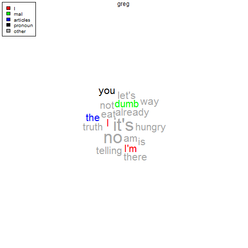

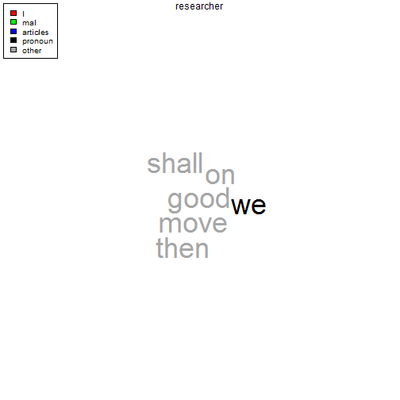

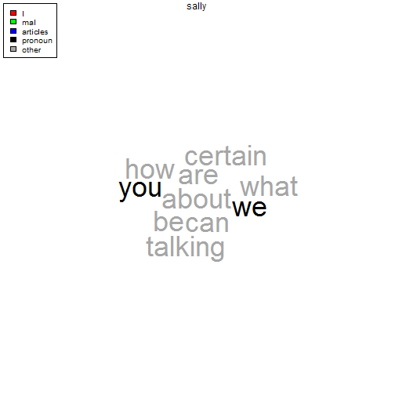

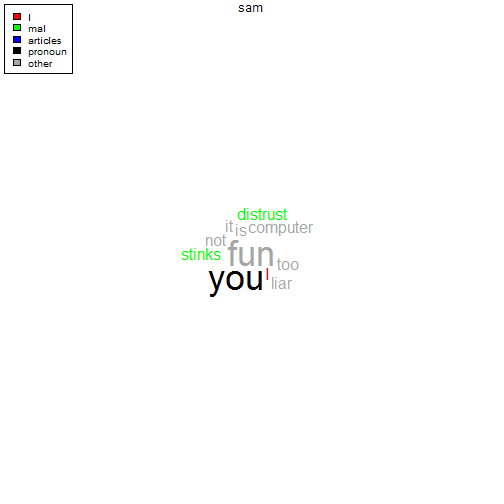

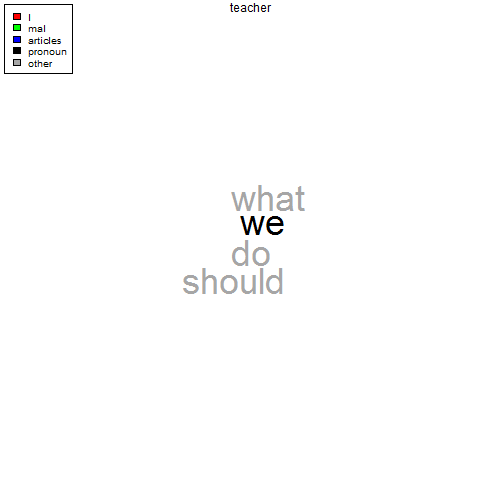

```r
## Generate themes/terms to color by
terms <- list(
    I=c("i", "i'm"),
    mal=qcv(stinks, dumb, distrust),
    articles=qcv(the, a, an),
    pronoun=qcv(we, you)
)

with(DATA, trans_cloud(state, person, target.words=terms,
    cloud.colors=qcv(red, green, blue, black, gray65),
    expand.target=FALSE, proportional=TRUE, legend=c(names(terms),
    "other")))
```

♦ **[`trans_cloud`](http://trinker.github.io/qdap_dev/trans_cloud.html) Example 2** - *Polarity*♦

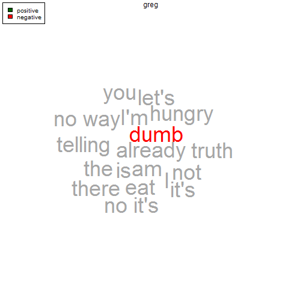

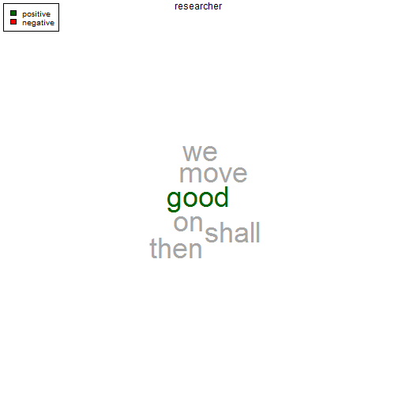

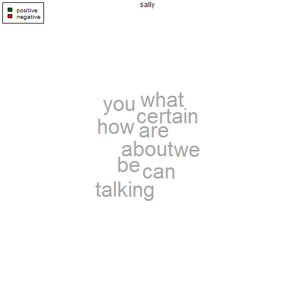

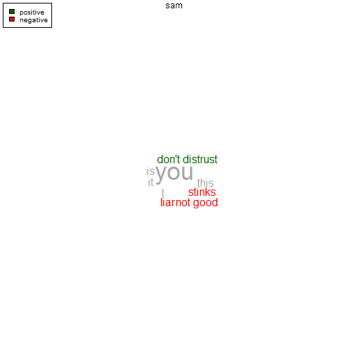

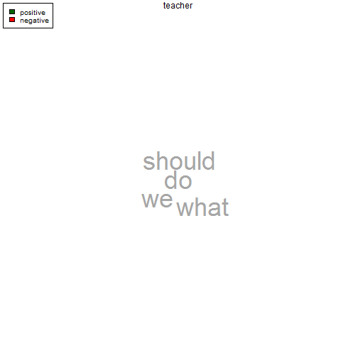

```r
## Rearrange the data
DATA2 <- qdap::DATA
DATA2[1, 4] <- "This is not good!"
DATA2[8, 4] <- "I don't distrust you."
DATA2$state <- space_fill(DATA2$state, paste0(negation.words, " "),
    rm.extra = FALSE)
txt <- gsub("~~", " ", breaker(DATA2$state))
rev.neg <- sapply(negation.words, paste, negative.words)
rev.pos <- sapply(negation.words, paste, positive.words)

## Generate themes/terms to color by
tw <- list(
    positive=c(positive.words, rev.neg[rev.neg %in% txt]),
    negative=c(negative.words, rev.pos[rev.pos %in% txt])
)

with(DATA2, trans_cloud(state, person,
    target.words=tw,
    cloud.colors=qcv(darkgreen, red, gray65),
    expand.target=FALSE, proportional=TRUE, legend=names(tw)))
```

♦ **[`gradient_cloud`](http://trinker.github.io/qdap_dev/gradient_cloud.html) Examples**♦

```r
## Fuse two words
DATA2 <- DATA
DATA2$state <- space_fill(DATA$state, c("is fun", "too fun", "you liar"))
```

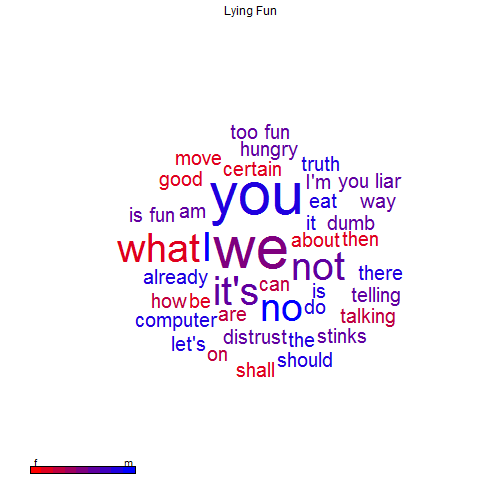

```r
gradient_cloud(DATA2$state, DATA2$sex, title="Lying Fun", max.word.size = 5,
    min.word.size = .025)
```

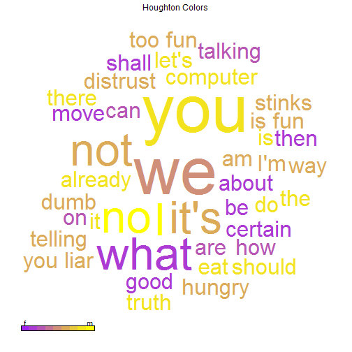

```r
gradient_cloud(DATA2$state, DATA2$sex, title="Houghton Colors",
    max.word.size = 8, min.word.size = .01, X ="purple" , Y = "yellow")
```

#### Gantt Plot

Many of the plot methods utilized by other functions' classes are a wrapper for [`gantt_plot`](http://trinker.github.io/qdap_dev/gantt_plot.html) or [`gantt_wrap`](http://trinker.github.io/qdap_dev/gantt_wrap.html). [`gantt_plot`](http://trinker.github.io/qdap_dev/gantt_plot.html) wraps the [`gantt`](http://trinker.github.io/qdap_dev/gantt.html), [`gantt_rep`](http://trinker.github.io/qdap_dev/gantt_rep.html) and [`gantt_wrap`](http://trinker.github.io/qdap_dev/gantt_wrap.html) functions to allow for direct input of text dialogue and grouping variables. The [`gantt_plot`](http://trinker.github.io/qdap_dev/gantt_plot.html) function is a fast way to make Gantt charts that can be faceted and filled by grouping variables. A Gantt plot allows the user to find trends and patterns in dialogue across time. It essentially allows for a visual representation of an entire exchange of dialogue. The following examples show the flexibility of [`gantt_plot`](http://trinker.github.io/qdap_dev/gantt_plot.html); many of these techniques can also be utilized in plot methods for qdap classes that utilize [`gantt_plot`](http://trinker.github.io/qdap_dev/gantt_plot.html) and [`gantt_wrap`](http://trinker.github.io/qdap_dev/gantt_wrap.html). It is also prudent to be aware of [`gantt_wrap`](http://trinker.github.io/qdap_dev/gantt_wrap.html), that is its arguments and how to utilize it, as it is less convenient yet more flexible and powerful than [`gantt_plot`](http://trinker.github.io/qdap_dev/gantt_plot.html).

♦ **[`gantt_plot`](http://trinker.github.io/qdap_dev/gantt_plot.html)** - *Single Time/Single Grouping Variable*♦

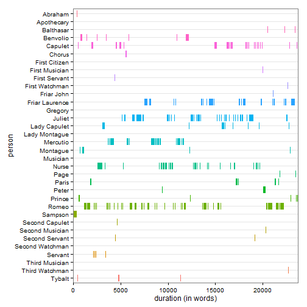

```r
with(rajSPLIT, gantt_plot(text.var = dialogue,
    grouping.var = person, size=4))
```

♦ **[`gantt_plot`](http://trinker.github.io/qdap_dev/gantt_plot.html)** - *Single Time/Multiple Grouping Variable*♦

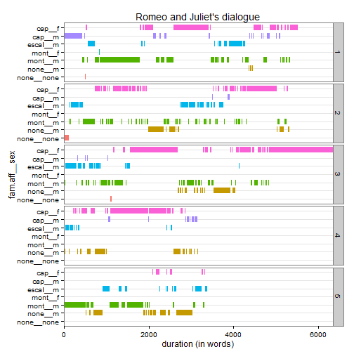

```r
with(rajSPLIT, gantt_plot(text.var = dialogue,
    grouping.var = list(fam.aff, sex), rm.var  = act,
    title = "Romeo and Juliet's dialogue"))
```

Sometimes the location of the facets may not be ideal to show the data (i.e., you may want to reverse the x and y axis). By setting **transform = TRUE** the user can make this switch.

♦ **[`gantt_plot`](http://trinker.github.io/qdap_dev/gantt_plot.html)** - *Transforming*♦

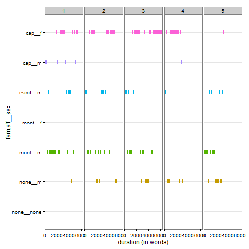

```r
with(rajSPLIT, gantt_plot(dialogue, list(fam.aff, sex), act,
    transform=T))
```

Often the default colors are less useful in displaying the trends in a way that is most meaningful. Because [`gantt_plot`](http://trinker.github.io/qdap_dev/gantt_plot.html) is a wrapper for ggplot2 the color palettes can easily be extended to use with the output from [`gantt_plot`](http://trinker.github.io/qdap_dev/gantt_plot.html).

♦ **[`gantt_plot`](http://trinker.github.io/qdap_dev/gantt_plot.html)** - *Color Palette Examples*♦

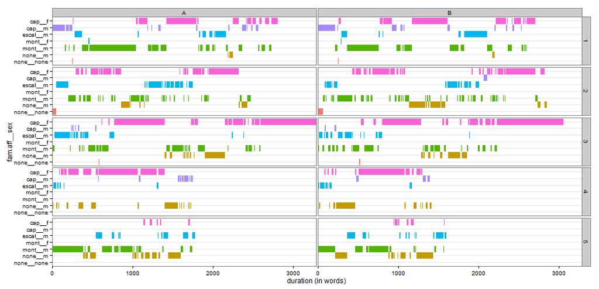

```r
## Load needed packages
library(ggplot2); library(scales); library(RColorBrewer); library(grid)

## Duplicate a new data set and make alterations
rajSPLIT2 <- rajSPLIT

rajSPLIT2$newb <- as.factor(sample(LETTERS[1:2], nrow(rajSPLIT2),
    replace=TRUE))

z <- with(rajSPLIT2, gantt_plot(dialogue, list(fam.aff, sex),
    list(act, newb), size = 4))
```

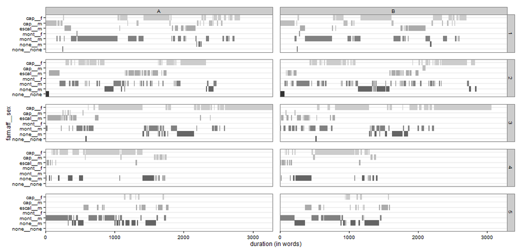

```r
z + theme(panel.spacing = unit(1, "lines")) + scale_colour_grey()
```

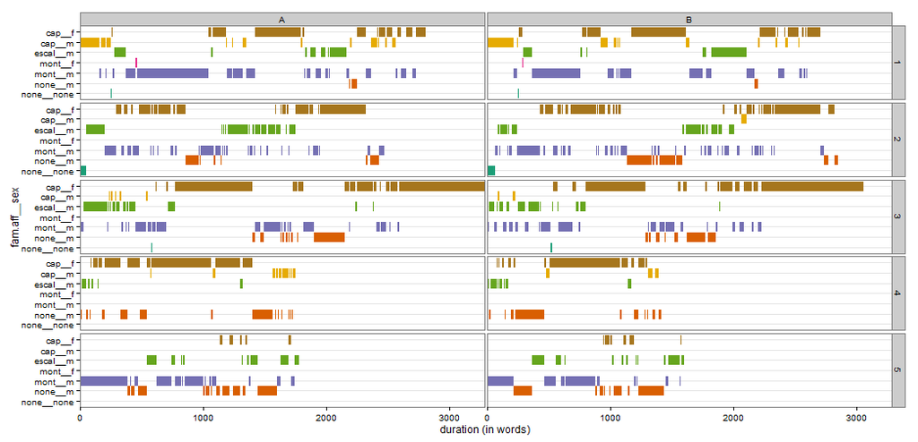

```r
z + scale_colour_brewer(palette="Dark2")
```